Supervised Learning Project

Author: Suresh Venkatesan

Objective: Predict likelihood of liability customer buying personal loans

# 1 Import necessary libraries

```python
import numpy as np
import pandas as pd
import matplotlib.pyplot as plt
import matplotlib as mpl
import seaborn as sns
sns.set(color_codes = True)
%matplotlib inline

from scipy import stats

# Preprocessing libraries
from sklearn.preprocessing import MinMaxScaler # MinMax Scaler
from sklearn.preprocessing import StandardScaler # Standard Scaler
from sklearn.preprocessing import RobustScaler # Robust Scaler

# Model libraries
from sklearn.dummy import DummyClassifier # Dummy classifier
from sklearn.linear_model import LogisticRegression # Logistic Regression Classifier
from sklearn.neighbors import KNeighborsClassifier # KNN classifier
from sklearn.naive_bayes import GaussianNB # Gaussian Naive Bayes classifier
from sklearn.naive_bayes import BernoulliNB # Bernoulli Naive Bayes classifier
from sklearn.svm import LinearSVC # Linear Support Vector Classifier
from sklearn.svm import SVC # Support Vector Machine classifer
from sklearn.ensemble import RandomForestClassifier # Random Forest Classifier
from sklearn.ensemble import GradientBoostingClassifier # Gradient Boosting Classifier

# Metric evaluation libraries
from sklearn.metrics import confusion_matrix # Compute confusion matrix.
from sklearn.metrics import f1_score # Compute f1 score.
from sklearn.metrics import classification_report # Generate classification report.
from sklearn.metrics import accuracy_score # Classification accuracy metric
from sklearn.metrics import precision_recall_curve # Plot recall vs. precision curve
from sklearn.metrics import average_precision_score # Compute average precision score.
from sklearn.metrics import roc_curve # Plot ROC curve
from sklearn.metrics import roc_auc_score # Compute AUC score

# Miscellaneous
from sklearn.model_selection import train_test_split # Split data into training and test sets
```

```python
# Set some plotting and printing ptions
mpl.rc('axes', labelsize = 30)
mpl.rc('axes', titlesize = 30)
mpl.rc('xtick', labelsize = 20)
mpl.rc('ytick', labelsize = 20)
mpl.rc('legend', fontsize = 20)
mpl.rc('figure', titlesize = 40)

pd.set_option('precision', 4) # Print 4 decimal places for all output parameters
```

# 2 Read the data as a data frame

```python
# Since the file is in .csv format, read_csv() command is used to read the data.
ploan_df = pd.read_csv('Bank_Personal_Loan_Modelling.csv')
display(ploan_df.head())
```

|  | ID | Age | Experience | Income | ZIP Code | Family | CCAvg | Education | Mortgage | Personal Loan | Securities Account | CD Account | Online | CreditCard |
| --- | --- | --- | --- | --- | --- | --- | --- | --- | --- | --- | --- | --- | --- | --- |
| 0 | 1 | 25 | 1 | 49 | 91107 | 4 | 1.6 | 1 | 0 | 0 | 1 | 0 | 0 | 0 |
| 1 | 2 | 45 | 19 | 34 | 90089 | 3 | 1.5 | 1 | 0 | 0 | 1 | 0 | 0 | 0 |
| 2 | 3 | 39 | 15 | 11 | 94720 | 1 | 1.0 | 1 | 0 | 0 | 0 | 0 | 0 | 0 |
| 3 | 4 | 35 | 9 | 100 | 94112 | 1 | 2.7 | 2 | 0 | 0 | 0 | 0 | 0 | 0 |
| 4 | 5 | 35 | 8 | 45 | 91330 | 4 | 1.0 | 2 | 0 | 0 | 0 | 0 | 0 | 1 |

**There are 14 columns in the data:**

```
1) ID: Customer ID.
2) Age: Age of Customer.
3) Experience: Number of years of professional experience.
4) Income: Annual income of customer in 1000's of dollars.
5) Zip Code: Home address zip code.
6) Family: Family size of the customer
7) CCAvg: Average spending on credit cards per month in 1000's of dollars.
8) Education: Education Level.
    1: Undergrad
    2: Graduate
    3: Advance / Professional
9) Mortgage: Value of house mortgage, if any in 1000's of dollars.
10) Personal Loan (target variable): Indicates whether the customer accepted the personal loan offered in the last campaign.
11) Securities Account: Indicates whether the customer has a securities account with the bank.
12) CD Account: Indicates whether the customer has a certificate of deposit (CD) account with the bank.
13) Online: Indicates whether the customer uses internet banking facilities.
14) CreditCard: Indicates whether the customer uses a credit card issued bythe bank.
```

**The response (output) variable is 'Personal Loan' which indicates whether the customer accepted the personal loan offered in the previous campaign.**

```python
# Drop ID column from dataframe since it will not be used for further processing
ploan_df.drop(columns = 'ID', inplace = True)
display(ploan_df.head())
```

|  | Age | Experience | Income | ZIP Code | Family | CCAvg | Education | Mortgage | Personal Loan | Securities Account | CD Account | Online | CreditCard |
| --- | --- | --- | --- | --- | --- | --- | --- | --- | --- | --- | --- | --- | --- |
| 0 | 25 | 1 | 49 | 91107 | 4 | 1.6 | 1 | 0 | 0 | 1 | 0 | 0 | 0 |
| 1 | 45 | 19 | 34 | 90089 | 3 | 1.5 | 1 | 0 | 0 | 1 | 0 | 0 | 0 |
| 2 | 39 | 15 | 11 | 94720 | 1 | 1.0 | 1 | 0 | 0 | 0 | 0 | 0 | 0 |
| 3 | 35 | 9 | 100 | 94112 | 1 | 2.7 | 2 | 0 | 0 | 0 | 0 | 0 | 0 |
| 4 | 35 | 8 | 45 | 91330 | 4 | 1.0 | 2 | 0 | 0 | 0 | 0 | 0 | 1 |

## 2.1 Data Types of each attribute

```python
# Print the data types of all columns
ploan_df.dtypes
```

```
Age                     int64
Experience              int64
Income                  int64
ZIP Code                int64
Family                  int64
CCAvg                 float64
Education               int64
Mortgage                int64
Personal Loan           int64
Securities Account      int64
CD Account              int64
Online                  int64
CreditCard              int64
dtype: object
```

**The data types of the following attributes needs to be changed from 'int64' to 'category' since they need to be interpreted as 'categorical variables:'**

```
1. Zip Code
2. Family
3. Education
4. Personal Loan
5. Securities Account
6. CD Account
7. Online
8. CreditCard
```

**Note:** 'Family' is treated as a categorical variable here. It isnt very clear if larger family sizes will have larger rates of personal loan acceptance. Hence, we will treat it as a categorical variable with no significance to the ordering of family size.

```python
# Convert the above mentioned columns to 'category' datatype.
# Create list of columns to convert to type category
cols_to_cat = ['ZIP Code', 'Family', 'Education', 'Personal Loan',\
            'Securities Account', 'CD Account', 'Online', 'CreditCard']
for ind in cols_to_cat:
    ploan_df[ind] = ploan_df[ind].astype('category')

ploan_df.dtypes
```

```
Age                      int64
Experience               int64
Income                   int64
ZIP Code              category
Family                category
CCAvg                  float64
Education             category
Mortgage                 int64
Personal Loan         category
Securities Account    category
CD Account            category
Online                category
CreditCard            category
dtype: object
```

## 2.2 Shape of the data

```python
ploan_df.shape
```

```
(5000, 13)
```

**There are 5000 entries (rows) and 13 variables (columns)**

## 2.3 Descriptive statistics summary of all columns

```python
# Get some descriptive statistics of all columns
ploan_df.describe(include = 'all')
```

|  | Age | Experience | Income | ZIP Code | Family | CCAvg | Education | Mortgage | Personal Loan | Securities Account | CD Account | Online | CreditCard |
| --- | --- | --- | --- | --- | --- | --- | --- | --- | --- | --- | --- | --- | --- |
| count | 5000.0000 | 5000.0000 | 5000.0000 | 5000.0 | 5000.0 | 5000.0000 | 5000.0 | 5000.0000 | 5000.0 | 5000.0 | 5000.0 | 5000.0 | 5000.0 |
| unique | NaN | NaN | NaN | 467.0 | 4.0 | NaN | 3.0 | NaN | 2.0 | 2.0 | 2.0 | 2.0 | 2.0 |
| top | NaN | NaN | NaN | 94720.0 | 1.0 | NaN | 1.0 | NaN | 0.0 | 0.0 | 0.0 | 1.0 | 0.0 |
| freq | NaN | NaN | NaN | 169.0 | 1472.0 | NaN | 2096.0 | NaN | 4520.0 | 4478.0 | 4698.0 | 2984.0 | 3530.0 |
| mean | 45.3384 | 20.1046 | 73.7742 | NaN | NaN | 1.9379 | NaN | 56.4988 | NaN | NaN | NaN | NaN | NaN |
| std | 11.4632 | 11.4680 | 46.0337 | NaN | NaN | 1.7477 | NaN | 101.7138 | NaN | NaN | NaN | NaN | NaN |
| min | 23.0000 | -3.0000 | 8.0000 | NaN | NaN | 0.0000 | NaN | 0.0000 | NaN | NaN | NaN | NaN | NaN |
| 25% | 35.0000 | 10.0000 | 39.0000 | NaN | NaN | 0.7000 | NaN | 0.0000 | NaN | NaN | NaN | NaN | NaN |
| 50% | 45.0000 | 20.0000 | 64.0000 | NaN | NaN | 1.5000 | NaN | 0.0000 | NaN | NaN | NaN | NaN | NaN |
| 75% | 55.0000 | 30.0000 | 98.0000 | NaN | NaN | 2.5000 | NaN | 101.0000 | NaN | NaN | NaN | NaN | NaN |
| max | 67.0000 | 43.0000 | 224.0000 | NaN | NaN | 10.0000 | NaN | 635.0000 | NaN | NaN | NaN | NaN | NaN |

## 2.4 Checking the presence of missing values

```python
ploan_df.isna().sum()
```

```
Age                   0
Experience            0
Income                0
ZIP Code              0
Family                0
CCAvg                 0
Education             0
Mortgage              0
Personal Loan         0
Securities Account    0
CD Account            0
Online                0
CreditCard            0
dtype: int64
```

**There are no missing elements in any of the columns**

## 2.5 Fix incorrect zip code value

- There is one ZIP Code value that is showing up as a 4-digit code (9307). Since all ZIP Codes in the US are 5-digit codes, we will convert this ZIP code to 93007.

```python
ploan_df[(ploan_df['ZIP Code'] == 9307)]
print("Before ZIP Code Fix")
print("===================")
display(ploan_df.iloc[[384]])
ploan_df['ZIP Code'].replace(9307, 93007, inplace = True)
print("After ZIP Code Fix")
print("==================")
display(ploan_df.iloc[[384]])
```

```
Before ZIP Code Fix
===================
```

|  | Age | Experience | Income | ZIP Code | Family | CCAvg | Education | Mortgage | Personal Loan | Securities Account | CD Account | Online | CreditCard |
| --- | --- | --- | --- | --- | --- | --- | --- | --- | --- | --- | --- | --- | --- |
| 384 | 51 | 25 | 21 | 9307 | 4 | 0.6 | 3 | 0 | 0 | 0 | 0 | 1 | 1 |

```
After ZIP Code Fix
==================
```

|  | Age | Experience | Income | ZIP Code | Family | CCAvg | Education | Mortgage | Personal Loan | Securities Account | CD Account | Online | CreditCard |
| --- | --- | --- | --- | --- | --- | --- | --- | --- | --- | --- | --- | --- | --- |
| 384 | 51 | 25 | 21 | 93007 | 4 | 0.6 | 3 | 0 | 0 | 0 | 0 | 1 | 1 |

# 3 Statistics of numeric predictors

## 3.1 Age

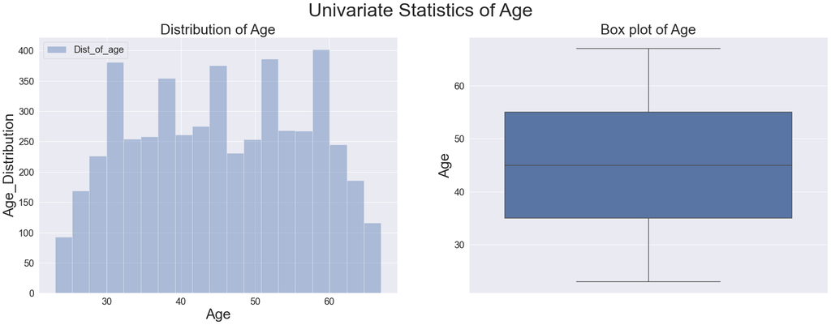

```python
# Age is a numeric variable. Get distribution and box plot
fig_1 = plt.figure(1, figsize = (30,10))
fig_1.suptitle('Univariate Statistics of Age')

ax1 = plt.subplot(1,2,1)
sns.distplot(ploan_df['Age'], kde = False, label = 'Dist_of_age')
ax1.set_title('Distribution of Age')
ax1.set_ylabel('Age_Distribution')
ax1.legend()

ax2 = plt.subplot(1,2,2)
sns.boxplot(y = 'Age', data = ploan_df)
ax2.set_title('Box plot of Age')
ax2.set_ylabel('Age')

plt.show()
```

- **Multimodel distribution seen from the distribution plot. No specific distribution pattern could be inferred from the distribution plot.**
- Distribution is fairly symmetric and no skewness seen.
- Box plot indicates no outliers.</b>

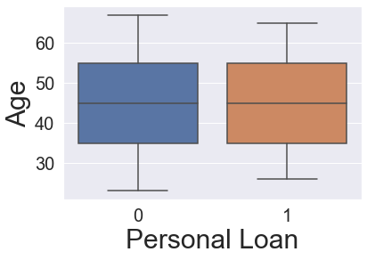

```python
sns.boxplot(x = 'Personal Loan', y = 'Age', data = ploan_df)
plt.show()
```

- **The above box plot shows no difference in the distribution of age between customers who accepted personal loan and those who did not.**
- Hence, it is expected that this feature will not have significant predictive behavior with respect to customer loan acceptance.</b>

## 3.2 Experience

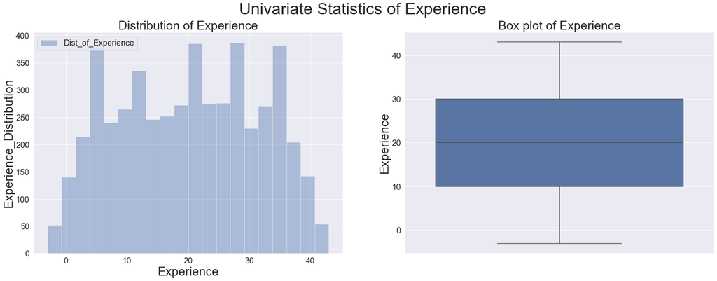

```python
# Experience is a numeric variable. Get distribution and box plot
fig_2 = plt.figure(2, figsize = (30,10))
fig_2.suptitle('Univariate Statistics of Experience')

ax1 = plt.subplot(1,2,1)
sns.distplot(ploan_df['Experience'], kde = False, label = 'Dist_of_Experience')
ax1.set_title('Distribution of Experience')
ax1.set_ylabel('Experience_Distribution')
ax1.legend()

ax2 = plt.subplot(1,2,2)
sns.boxplot(y = 'Experience', data = ploan_df)
ax2.set_title('Box plot of Experience')
ax2.set_ylabel('Experience')

plt.show()
```

- **Multimodel distribution seen from the distribution plot. No specific distribution pattern could be inferred from the distribution plot.**
- Distribution is fairly symmetric and no skewness seen.
- Box plot indicates no outliers.
- There are some members with negative experience seen in the distribution plot. It is assumed that these are probably students who do not have any work experience. These negative values will be used as they are in the model building process.</b>

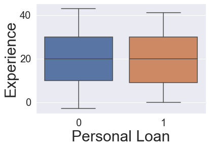

```python
sns.boxplot(x = 'Personal Loan', y = 'Experience', data = ploan_df)
plt.show()
```

- **The above box plot shows no difference in the distribution of experience between customers who accepted personal loan and those who did not.**
- Hence, it is expected that this feature will not have significant predictive behavior with respect to customer loan acceptance.</b>

## 3.3 Income

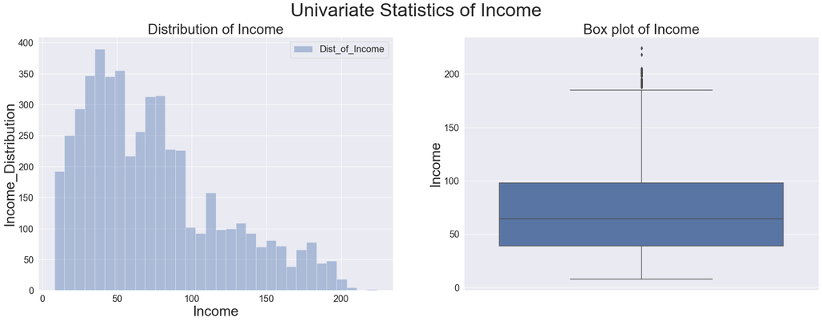

```python
# Income is a numeric variable. Get distribution and box plot
fig_3 = plt.figure(3, figsize = (30,10))
fig_3.suptitle('Univariate Statistics of Income')

ax1 = plt.subplot(1,2,1)
sns.distplot(ploan_df['Income'], kde = False, label = 'Dist_of_Income')
ax1.set_title('Distribution of Income')
ax1.set_ylabel('Income_Distribution')
ax1.legend()

ax2 = plt.subplot(1,2,2)
sns.boxplot(y = 'Income', data = ploan_df)
ax2.set_title('Box plot of Income')
ax2.set_ylabel('Income')

plt.show()
```

- **Right-skewed distribution seen from the distribution plot.**
- Box plot indicates some outliers.</b>

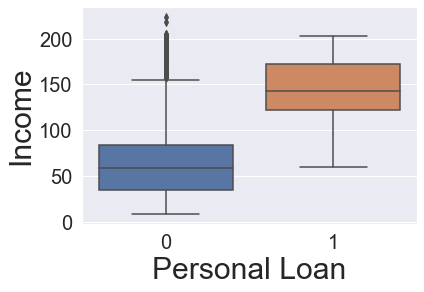

```python
sns.boxplot(x = 'Personal Loan', y = 'Income', data = ploan_df)
plt.show()
```

- **The above box plot shows a clear difference in the distribution of income between customers who accepted personal loan and those who did not. Customers with higher income tend to have a higher acceptance of personal loan which makes sense.**
- This feature is expected to have significant predictive impact on customer personal loan acceptance.</b>

## 3.4 CCAvg

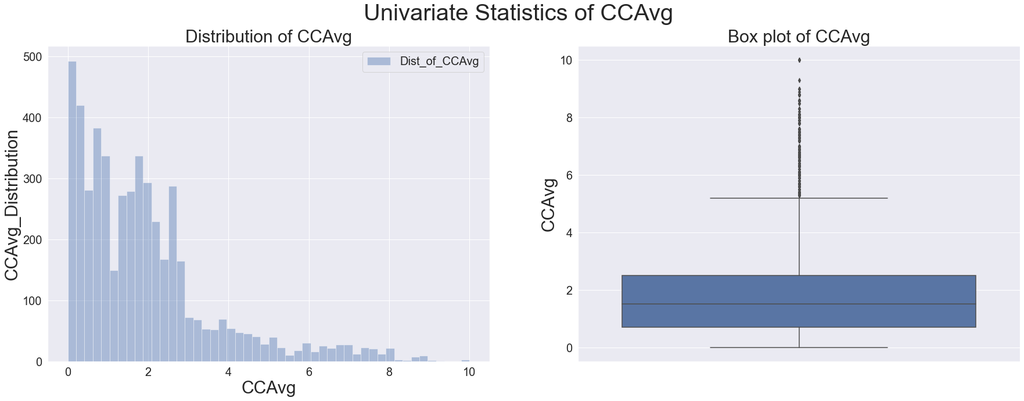

```python
# CCAvg is a numeric variable. Get distribution and box plot
fig_4 = plt.figure(4, figsize = (30,10))
fig_4.suptitle('Univariate Statistics of CCAvg')

ax1 = plt.subplot(1,2,1)
sns.distplot(ploan_df['CCAvg'], kde = False, label = 'Dist_of_CCAvg')
ax1.set_title('Distribution of CCAvg')
ax1.set_ylabel('CCAvg_Distribution')
ax1.legend()

ax2 = plt.subplot(1,2,2)
sns.boxplot(y = 'CCAvg', data = ploan_df)
ax2.set_title('Box plot of CCAvg')
ax2.set_ylabel('CCAvg')

plt.show()
```

- **Heavily right-skewed distribution seen from the distribution plot.**
- Box plot indicates many outliers.</b>

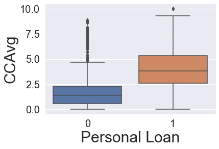

```python
sns.boxplot(x = 'Personal Loan', y = 'CCAvg', data = ploan_df)
plt.show()
```

- **The above box plot shows a difference in the distribution of CCAvg between customers who accepted personal loan and those who did not. Customers with higher average spending on credit cards per month tend to have a higher acceptance of personal loan.**
- This feature is expected to have some predictive impact on customer personal loan acceptance.</b>

## 3.5 Mortgage

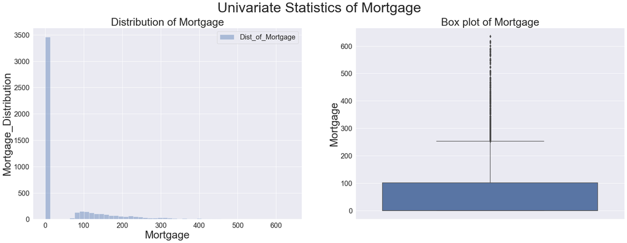

```python
# Mortgage is a numeric variable. Get distribution and box plot
fig_5 = plt.figure(5, figsize = (30,10))
fig_5.suptitle('Univariate Statistics of Mortgage')

ax1 = plt.subplot(1,2,1)
sns.distplot(ploan_df['Mortgage'], kde = False, label = 'Dist_of_Mortgage')
ax1.set_title('Distribution of Mortgage')
ax1.set_ylabel('Mortgage_Distribution')
ax1.legend()

ax2 = plt.subplot(1,2,2)
sns.boxplot(y = 'Mortgage', data = ploan_df)
ax2.set_title('Box plot of Mortgage')
ax2.set_ylabel('Mortgage')

plt.show()
```

- **Distribution indicates that almost around 3500 customers have no mortgage. A small percentage of customers have mortgage in the range of 70K to 500K dollars.**

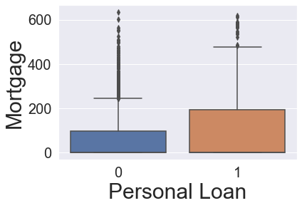

```python
sns.boxplot(x = 'Personal Loan', y = 'Mortgage', data = ploan_df)
plt.show()
```

- **No clear relationship seen between outstanding mortgage and personal loan acceptance.**
- This predictor is not expected to have significant predictive effect on customer loan acceptance.</b>

## 3.6 5-point summary of numerical attributes

```python
# Generate 5-point summary for all numeric attributes
ploan_df_fps = ploan_df.quantile(q = [0, 0.25, 0.5, 0.75, 1], axis = 0)

# Set appropriate index names for 5-point summary table
ploan_df_fps['Index'] = ['Min', 'Q1', 'Q2', 'Q3', 'Max']
ploan_df_fps.set_index('Index', inplace = True)

# Display 5-point summary for all numeric attributes
display(ploan_df_fps)
```

| Index | Age | Experience | Income | CCAvg | Mortgage |
| --- | --- | --- | --- | --- | --- |
| Min | 23.0 | -3.0 | 8.0 | 0.0 | 0.0 |
| Q1 | 35.0 | 10.0 | 39.0 | 0.7 | 0.0 |
| Q2 | 45.0 | 20.0 | 64.0 | 1.5 | 0.0 |
| Q3 | 55.0 | 30.0 | 98.0 | 2.5 | 101.0 |
| Max | 67.0 | 43.0 | 224.0 | 10.0 | 635.0 |

## 3.7 Checking presence of outliers in numeric columns

```python
# Obtain inter-quartile range (IQR) for all three numeric variables.
iqr = ploan_df_fps.loc['Q3'] - ploan_df_fps.loc['Q1']

# Obtain the min and max thresholds used to check for presence of outliers
# Min threshold = Q1 - 1.5 * IQR
# Max threshold = Q3 + 1.5 * IQR
q1_m_1P5iqr = ploan_df_fps.loc['Q1'] - 1.5 * iqr
q3_p_1P5iqr = ploan_df_fps.loc['Q3'] + 1.5 * iqr

# Compute number of outliers in all numeric attributes.
num_out_age  = ((ploan_df['Age'] < q1_m_1P5iqr['Age'])\
                | (ploan_df['Age'] > q3_p_1P5iqr['Age'])).sum()
num_out_exp = ((ploan_df['Experience'] < q1_m_1P5iqr['Experience'])\
               | (ploan_df['Experience'] > q3_p_1P5iqr['Experience'])).sum()
num_out_inc = ((ploan_df['Income'] < q1_m_1P5iqr['Income'])\
               | (ploan_df['Income'] > q3_p_1P5iqr['Income'])).sum()
num_out_cca = ((ploan_df['CCAvg'] < q1_m_1P5iqr['CCAvg'])\
               | (ploan_df['CCAvg'] > q3_p_1P5iqr['CCAvg'])).sum()
num_out_mor = ((ploan_df['Mortgage'] < q1_m_1P5iqr['Mortgage'])\
               | (ploan_df['Mortgage'] > q3_p_1P5iqr['Mortgage'])).sum()

print("Number of outliers in 'Age' is {}".format(num_out_age))
print("Number of outliers in 'Experience' is {}".format(num_out_exp))
print("Number of outliers in 'Income' is {}".format(num_out_inc))
print("Number of outliers in 'CCAvg' is {}".format(num_out_cca))
print("Number of outliers in 'Mortgage' is {}".format(num_out_mor))
```

```
Number of outliers in 'Age' is 0
Number of outliers in 'Experience' is 0
Number of outliers in 'Income' is 96
Number of outliers in 'CCAvg' is 324
Number of outliers in 'Mortgage' is 291
```

## 3.8 Measure of skewness of numeric variables

```python
# Based on Fisher-Pearson coefficient of skewness
print("Skewness coefficient for Age is %0.3f" %\
      stats.skew(ploan_df['Age'], bias = False))
print("Skewness coefficient for Experience is %0.3f" %\
      stats.skew(ploan_df['Experience'], bias = False))
print("Skewness coefficient for Income is %0.3f" %\
      stats.skew(ploan_df['Income'], bias = False))
print("Skewness coefficient for average credit card spending is %0.3f" %\
      stats.skew(ploan_df['CCAvg'], bias = False))
print("Skewness coefficient for house mortgage is %0.3f" %\
      stats.skew(ploan_df['Mortgage'], bias = False))
```

```
Skewness coefficient for Age is -0.029
Skewness coefficient for Experience is -0.026
Skewness coefficient for Income is 0.841
Skewness coefficient for average credit card spending is 1.598
Skewness coefficient for house mortgage is 2.104
```

**Based on the skewness coefficient numbers above, we can conclude that 'Age' and 'Experience' are symmetric distributions while 'Income', 'CCAvg', and 'Mortgage' have a significiant positive / right skew.**

# 4 Statistics of categorical predictors

## 4.1 Frequency Tables of the categorical columns

```python
# ZIP Code
print(ploan_df['ZIP Code'].nunique())
```

```
467
```

**There are 467 unique values of ZIP Code. Looking at value counts of all these 467 distinct values will not provide too much information and hence it is not reported here.**

```python
# Family Size
print(ploan_df['Family'].value_counts())
```

```
1    1472
2    1296
4    1222
3    1010
Name: Family, dtype: int64
```

**There are four unique values for family size and there is almost equal distribution amongst the four values.**

```python
# Education Level
print(ploan_df['Education'].value_counts())
```

```
1    2096
3    1501
2    1403
Name: Education, dtype: int64
```

**There are three unique values for Education level (1: Undergrad, 2: Graduate, 3: Advanced / Professional). Customers with undergrad education represent about 40% of the customers, while customers with graduate and advanced degrees represent about 30% of the total customer base each.**

```python
# Indicates whether customer has a 'Securities Account' with bank
print(ploan_df['Securities Account'].value_counts())
```

```
0    4478
1     522
Name: Securities Account, dtype: int64
```

**This distribution is heavily skewed with only around 10% of the customers having a securities account.**

```python
# Indicates whether customer has a 'CD Account' with bank
print(ploan_df['CD Account'].value_counts())
```

```
0    4698
1     302
Name: CD Account, dtype: int64
```

**This distribution is heavily skewed with only around 6% of the customers having a CD account.**

```python
# Indicates whether customer uses internet banking facilities
print(ploan_df['Online'].value_counts())
```

```
1    2984
0    2016
Name: Online, dtype: int64
```

**Around 60% of the customers use internet banking facilities while the remaining 40% don't.**

```python
# Indicates whether customer uses a credit card issued by UniversalBank
print(ploan_df['CreditCard'].value_counts())
```

```
0    3530
1    1470
Name: CreditCard, dtype: int64
```

**Around 30% of the customers use a credit card issued by Universal Bank while the remaining 70% don't.**

## 4.2 Count plots of the categorical columns

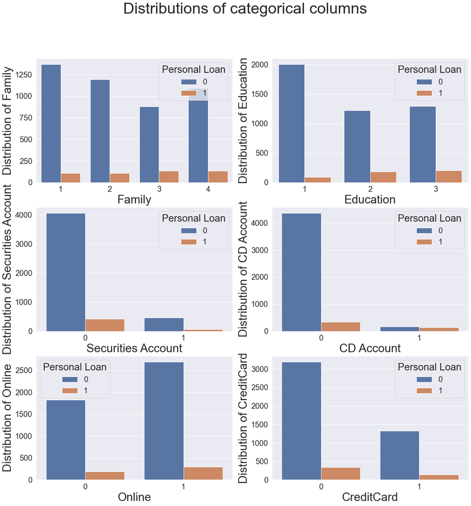

```python
fig_6 = plt.figure(6, figsize = (20,20))
fig_6.suptitle('Distributions of categorical columns')

ax1 = plt.subplot(3,2,1)
sns.countplot('Family', hue = 'Personal Loan', data = ploan_df)
ax1.set_ylabel('Distribution of Family')

ax2 = plt.subplot(3,2,2)
sns.countplot('Education', hue = 'Personal Loan', data = ploan_df)
ax2.set_ylabel('Distribution of Education')

ax3 = plt.subplot(3,2,3)
sns.countplot('Securities Account', hue = 'Personal Loan', data = ploan_df)
ax3.set_ylabel('Distribution of Securities Account')

ax4 = plt.subplot(3,2,4)
sns.countplot('CD Account', hue = 'Personal Loan', data = ploan_df)
ax4.set_ylabel('Distribution of CD Account')

ax5 = plt.subplot(3,2,5)
sns.countplot('Online', hue = 'Personal Loan', data = ploan_df)
ax5.set_ylabel('Distribution of Online')

ax6 = plt.subplot(3,2,6)
sns.countplot('CreditCard', hue = 'Personal Loan', data = ploan_df)
ax6.set_ylabel('Distribution of CreditCard')

plt.show()
```

## 4.3 Cross-tabs of the categorical columns

```python
ct_pl_sa = pd.crosstab(ploan_df['Personal Loan'],ploan_df['Securities Account'], margins = True)
display(ct_pl_sa)
print("Percentage of individuals who don't have securities account and accepted personal loan: \
%0.2f" % ((100 * ct_pl_sa.iloc[1, 0]) / (ct_pl_sa.iloc[0, 0] + ct_pl_sa.iloc[1, 0])))
print("Percentage of individuals who have securities account and accepted personal loan: \
%0.2f" % ((100 * ct_pl_sa.iloc[1, 1]) / (ct_pl_sa.iloc[0, 1] + ct_pl_sa.iloc[1, 1])))
```

| Securities Account Personal Loan | 0 | 1 | All |
| --- | --- | --- | --- |
| 0 | 4058 | 462 | 4520 |
| 1 | 420 | 60 | 480 |
| All | 4478 | 522 | 5000 |

```
Percentage of individuals who don't have securities account and accepted personal loan: 9.38
Percentage of individuals who have securities account and accepted personal loan: 11.49
```

**From the data above, it seems like there is no major difference in the personal loan acceptance rate between individuals who have securities account and those who don't.**

This feature is not expected to have significant predictive effect on the customer personal loan acceptance.</b>

```python
ct_pl_ca = pd.crosstab(ploan_df['Personal Loan'],ploan_df['CD Account'], margins = True)
display(ct_pl_ca)
print("Percentage of individuals who don't have CD account and accepted personal loan : \
%0.2f" % ((100 * ct_pl_ca.iloc[1, 0]) / (ct_pl_ca.iloc[0, 0] + ct_pl_ca.iloc[1, 0])))
print("Percentage of individuals who have CD account and accepted personal loan: \
%0.2f" % ((100 * ct_pl_ca.iloc[1, 1]) / (ct_pl_ca.iloc[0, 1] + ct_pl_ca.iloc[1, 1])))
```

| CD Account Personal Loan | 0 | 1 | All |
| --- | --- | --- | --- |
| 0 | 4358 | 162 | 4520 |
| 1 | 340 | 140 | 480 |
| All | 4698 | 302 | 5000 |

```
Percentage of individuals who don't have CD account and accepted personal loan : 7.24
Percentage of individuals who have CD account and accepted personal loan: 46.36
```

**From the data above, we can see that there is a significant difference in the personal loan acceptance rate between individuals who have CD account and those who don't.**

This feature is expected to have significant predictive effect on the customer personal loan acceptance.</b>

```python
ct_pl_on = pd.crosstab(ploan_df['Personal Loan'],ploan_df['Online'], margins = True)
display(ct_pl_on)
print("Percentage of individuals who don't have online account and accepted personal loan: \
%0.2f" % ((100 * ct_pl_on.iloc[1, 0]) / (ct_pl_on.iloc[0, 0] + ct_pl_on.iloc[1, 0])))
print("Percentage of individuals who have online account and accepted personal loan: \
%0.2f" % ((100 * ct_pl_on.iloc[1, 1]) / (ct_pl_on.iloc[0, 1] + ct_pl_on.iloc[1, 1])))
```

| Online Personal Loan | 0 | 1 | All |
| --- | --- | --- | --- |
| 0 | 1827 | 2693 | 4520 |
| 1 | 189 | 291 | 480 |
| All | 2016 | 2984 | 5000 |

```
Percentage of individuals who don't have online account and accepted personal loan: 9.38
Percentage of individuals who have online account and accepted personal loan: 9.75
```

**From the data above, it seems like there is no major difference in the personal loan acceptance rate between individuals who have internet banking facilities and those who don't.**

This feature is not expected to have significant predictive effect on the customer personal loan acceptance.</b>

```python
ct_pl_cc = pd.crosstab(ploan_df['Personal Loan'],ploan_df['CreditCard'], margins = True)
display(ct_pl_cc)
print("Percentage of individuals who don't have a CC from the bank and accepted personal loan: \
%0.2f" % ((100 * ct_pl_cc.iloc[1, 0]) / (ct_pl_cc.iloc[0, 0] + ct_pl_cc.iloc[1, 0])))
print("Percentage of individuals who have a CC from the bank and accepted personal loan: \
%0.2f" % ((100 * ct_pl_cc.iloc[1, 1]) / (ct_pl_cc.iloc[0, 1] + ct_pl_cc.iloc[1, 1])))
```

| CreditCard Personal Loan | 0 | 1 | All |
| --- | --- | --- | --- |
| 0 | 3193 | 1327 | 4520 |
| 1 | 337 | 143 | 480 |
| All | 3530 | 1470 | 5000 |

```
Percentage of individuals who don't have a CC from the bank and accepted personal loan: 9.55
Percentage of individuals who have a CC from the bank and accepted personal loan: 9.73
```

**From the data above, it seems like there is no major difference in the personal loan acceptance rate between individuals who have a credit card issued by UniversalBank and those who don't.**

This feature is not expected to have significant predictive effect on the customer personal loan acceptance.</b>

```python
ct_pl_ed = pd.crosstab(ploan_df['Personal Loan'],ploan_df['Education'], margins = True)
display(ct_pl_ed)
print("Percentage of individuals who have an undergrad degree and accepted personal loan: \
%0.2f" % ((100 * ct_pl_ed.iloc[1, 0]) / (ct_pl_ed.iloc[0, 0] + ct_pl_ed.iloc[1, 0])))
print("Percentage of individuals who have a graduate degree and accepted personal loan: \
%0.2f" % ((100 * ct_pl_ed.iloc[1, 1]) / (ct_pl_ed.iloc[0, 1] + ct_pl_ed.iloc[1, 1])))
print("Percentage of individuals who have an advanced degree and accepted personal loan: \
%0.2f" % ((100 * ct_pl_ed.iloc[1, 2]) / (ct_pl_ed.iloc[0, 2] + ct_pl_ed.iloc[1, 2])))
```

| Education Personal Loan | 1 | 2 | 3 | All |
| --- | --- | --- | --- | --- |
| 0 | 2003 | 1221 | 1296 | 4520 |
| 1 | 93 | 182 | 205 | 480 |
| All | 2096 | 1403 | 1501 | 5000 |

```
Percentage of individuals who have an undergrad degree and accepted personal loan: 4.44
Percentage of individuals who have a graduate degree and accepted personal loan: 12.97
Percentage of individuals who have an advanced degree and accepted personal loan: 13.66
```

**From the data above, we can see that individuals who have only an undergrad degree tend to have a lower personal loan acceptance rate. Individuals with graduate and advanced degrees have a higher personal loan acceptance rate.**

This feature is expected to have some predictive impact on the customer personal loan acceptance.</b>

```python
ct_pl_fm = pd.crosstab(ploan_df['Personal Loan'],ploan_df['Family'], margins = True)
display(ct_pl_fm)
print("Percentage of individuals whose family size is 1 and accepted personal loan: \
%0.2f" % ((100 * ct_pl_fm.iloc[1, 0]) / (ct_pl_fm.iloc[0, 0] + ct_pl_fm.iloc[1, 0])))
print("Percentage of individuals whose family size is 2 and accepted personal loan: \
%0.2f" % ((100 * ct_pl_fm.iloc[1, 1]) / (ct_pl_fm.iloc[0, 1] + ct_pl_fm.iloc[1, 1])))
print("Percentage of individuals whose family size is 3 and accepted personal loan: \
%0.2f" % ((100 * ct_pl_fm.iloc[1, 2]) / (ct_pl_fm.iloc[0, 2] + ct_pl_fm.iloc[1, 2])))
print("Percentage of individuals whose family size is 4 and accepted personal loan: \
%0.2f" % ((100 * ct_pl_fm.iloc[1, 3]) / (ct_pl_fm.iloc[0, 3] + ct_pl_fm.iloc[1, 3])))
```

| Family Personal Loan | 1 | 2 | 3 | 4 | All |
| --- | --- | --- | --- | --- | --- |
| 0 | 1365 | 1190 | 877 | 1088 | 4520 |
| 1 | 107 | 106 | 133 | 134 | 480 |
| All | 1472 | 1296 | 1010 | 1222 | 5000 |

```
Percentage of individuals whose family size is 1 and accepted personal loan: 7.27
Percentage of individuals whose family size is 2 and accepted personal loan: 8.18
Percentage of individuals whose family size is 3 and accepted personal loan: 13.17
Percentage of individuals whose family size is 4 and accepted personal loan: 10.97
```

**Larger Families(size 3 and 4) tend to have slightly higher personal loan acceptance rates than smaller families.**

This feature is expected to have a small predictive impact on the customer personal loan acceptance rate.</b>

# 5 Target column distribution

- **Positive class** is defined as the class when a customer accepted the personal loan in the last campaign (Personal Loan = 1).
- **Negative class** is defined as the class when a customer did not accept the personal loan in the last campaign (Personal Loan = 0).

## 5.1 Count plot of target column

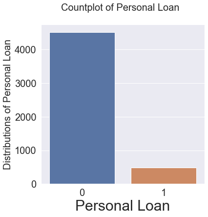

```python
fig_7 = plt.figure(7, figsize = (6, 6))
fig_7.suptitle('Countplot of Personal Loan', fontsize = 20)

ax1 = plt.subplot(1,1,1)
sns.countplot(ploan_df['Personal Loan'])
ax1.set_ylabel('Distributions of Personal Loan', fontsize = 20)
plt.show()
```

## 5.2 Value counts of target column

```python
# Compute distribution of positive and negative classes
TC_PC_FDS = ploan_df['Personal Loan'].value_counts()[1] # True class; Positive Count; Full dataset
TC_NC_FDS = ploan_df['Personal Loan'].count() - TC_PC_FDS # True class; Negative count; Full dataset

print("Number of customers who did not accept personal loan in last campaign is %d" %TC_NC_FDS)
print("Number of customers who accepted personal loan in last campaign is %d" %TC_PC_FDS)
print('')
print("Percentage of customers who did not accept personal loan in last campaign is %0.2f %%"\
      %(100 * TC_NC_FDS / (TC_NC_FDS + TC_PC_FDS)))
print("Percentage of customers who accepted personal loan in last campaign is %0.2f %%"\
      %(100 * TC_PC_FDS / (TC_NC_FDS + TC_PC_FDS)))
```

```
Number of customers who did not accept personal loan in last campaign is 4520
Number of customers who accepted personal loan in last campaign is 480

Percentage of customers who did not accept personal loan in last campaign is 90.40 %
Percentage of customers who accepted personal loan in last campaign is 9.60 %
```

**The above data indicates that this is a highly imbalanced dataset. Only 9.6% of the full dataset belongs to the positive class. Given this, we cannot used only classification accuracy as a metric to evaluate the performance of the various models.**

We need to maximimize the recall(TPR) so that we can classify most of the customers who are actually likely to buy personal loans into the positive class (Personal Loan = 1). At the same time, we also want to minimize the False Positive Rate (FPR) so that we classify most of the customers who are actually not likely to buy personal loans into the negative class (Personal Loan = 0).

Given the nature of this dataset and the problem statement, the AUC metric (Area under the ROC curve) will be used as the main metric to compare between different classifiers.</b>

# 6 Helper Functions

- In this section, we will define multiple helper functions which will be used later in the code for pre-processing inputs, fitting models, evaluating and plotting various metrics.

## 6.1 Zip Code Mapper

- The dataset has a feature called "ZIP Code" which refers to the home address ZIP Code.
- This feature has to be treated as a categorical variable and there are 467 unique values of this feature.
- One option would be to one-hot encode all the 467 levels. However, this may not be very meaningful as each individual zip-code will not have much predictive value. Also, several zipcodes appear in the dataset only once which also implies that one-hot encoding of the zip-code levels may not be a good idea.
- **The approach taken here is to derive two new features from "ZIP Code":**
  - **First new feature:** We first find the frequency of occurence of each zip code in the dataset. This is the number of times a particular zip code appears in the dataset. We then group the zip codes into multiple bins depending on their frequency of occurence. For instance, we could group all zip codes that appear less than 25 times in the dataset into a single group 'G1'. All zip codes that appear between 25 and 100 times could be grouped together into another group 'G2' and so on. This new feature will then be treated as a categorical feature and will have much lesser number of levels which can then be one-hot encoded.
  - **Second new feature:** For the second feature, we evaluate the percentage of customers within that zip code who accepted the personal loan offered in the last campaign. For e.g: if there are 20 users in a particular zip code and 5 of them accepted the personal loan , then the second feature will evaluate to 5/20 = 0.25 for that particular zip code. This feature will then be treated as a continuous numeric feature and passed to the model as such.

```python
def zip_code_mapper(df_orig, zc_col_name, zc_freq_col_name, zc_bins,\
                   zc_bin_labels, out_var, zc_score_col_name):

    """
    Function to map ZIP Codes to two new features.

    Arguments:
        df_orig: Name of the original dataframe containing ZIP Code column.
        zc_col_name: Name of the column containing ZIP Codes.
        zc_freq_col_name: Name of the column to store the 'First new feature'
        zc_bins: Bin edges to group together zip codes based on frequency
        zc_bin_labels: Labels to use for each group created based on zc_bins
        out_var: Name of the column containing the output variable.
        zc_score_col_name: Name of the column to store the 'Second new feature'

    Returns:
        df_new: New dataframe containing the two new features. Original zip code column
        will be dropped from this dataframe

    """

    zc_freq_df = df_orig[zc_col_name].value_counts().reset_index(name = zc_freq_col_name).\
    rename(columns = {'index' : zc_col_name})
    bins = zc_bins
    bin_labels = zc_bin_labels
    zc_freq_df[zc_freq_col_name] = pd.cut(zc_freq_df[zc_freq_col_name], bins, labels = bin_labels)
    df_new = df_orig.copy()
    df_new = pd.merge(df_orig, zc_freq_df, on = zc_col_name, how = 'left')

    zc_out_var_ct = pd.crosstab(df_orig[zc_col_name], df_orig[out_var], normalize = 'index')
    zc_out_var_ct.rename_axis(None, axis = 1, inplace = True)
    zc_out_var_ct.drop(columns = 0, inplace = True)
    zc_out_var_ct.rename(columns = {1 : zc_score_col_name}, inplace = True)
    zc_out_var_ct.reset_index(inplace = True)
    df_new = pd.merge(df_new, zc_out_var_ct, on = zc_col_name, how = 'left')
    df_new.drop(columns = zc_col_name, inplace = True)

    return df_new
```

## 6.2 Normalize numeric columns

- This function is used to fit different scalers to different columns and return the scaled columns for both the training and test sets in new dataframes. The original unscaled columns will be dropped in the the new dataframes.

```python
def norm_num_feat(X_train_us, X_test_us, scal_dict):

    """
    Function to normalize multiple columns of X_train_us and X_test_us using the data provided in
    scal_dict.

    Arguments:
        X_train_us - Training set features with unscaled numeric columns
        X_test_us - Test set features with unscaled numeric columns
        scal_dict: Dictionary of columns to be scaled and scalers to be applied on each column
                   Key of scal_dict = S.No of column to be scaled.
                   Each entry of clfs is a list with the name of the column to be scaled,
                   name to use for the scaled column, type of the scaler.
                   Type of the scaler:
                       mm_sc refers to MinMaxScaler.
                       st_sc refers to StandardScaler.
                       rb_sc refers to RobustScaler.

    Returns:
        X_train_sc - Training set features with scaled numeric columns.
        X_test_sc - Test set features with scaled numeric columns.

    """

    # Create copies of the unscaled training and test sets.
    X_train_sc = X_train_us.copy()
    X_test_sc = X_test_us.copy()

    for ind in range(len(scal_dict)):
        us_col_name = scal_dict[ind][0]
        sc_col_name = scal_dict[ind][1]

        if scal_dict[ind][2] == 'mm_sc':
            scaler = MinMaxScaler()
        elif scal_dict[ind][2] == 'st_sc':
            scaler = StandardScaler()
        elif scal_dict[ind][2] == 'rb_sc':
            scaler = RobustScaler()

        scaler.fit(X_train_us[[us_col_name]])
        X_train_sc[sc_col_name] = scaler.transform(X_train_us[[us_col_name]])
        X_train_sc.drop(columns = us_col_name, inplace = True)
        X_test_sc[sc_col_name] = scaler.transform(X_test_us[[us_col_name]])
        X_test_sc.drop(columns = us_col_name, inplace = True)

    return X_train_sc, X_test_sc
```

## 6.3 Define mixed naive bayes model

- Before training all the models, let's define a custom mixed naive bayes model.
- The reason for doing this is as follows: Scikit-Learn provides naive bayes models which can either handle binomial / multinomial features or numeric features which are assumed to have a Gaussian distribution.
- In this case, we have a mix of binary features (including original binary features and one-hot encoded categorical features) and numeric features.
- To handle this case, we will split the features into binary features and numeric features. We will fit the binary features using a Bernoulli Naive Bayes model and the numeric features using a Gaussian Naive Bayes model.
- The posterior probabilities will then be extracted from both models and combined together to generate the overall posterior probability.

```python
# Function to fit Mixed Naive Bayes model
def MixedNB_fit(X_train, y_train, nb_bin_cols, nb_num_cols):

    """
    Function to fit a mixed naive Bayes model.
    The 'nb_bin_cols' of X_train (binary columns of X_train) will be fit using Bernoulli NB.
    The 'nb_num_cols' of X_train (numeric columns of X_train) will be fit using Gaussian NB.

    Arguments:
        X_train - Training set features
        y_train - Training set output
        nb_bin_cols - List of binary columns to use with Bernoulli Naive Bayes
        nb_num_cols - List of numeric columns to use with Gaussian Naive Bayes

    Returns:
        bnb - Model fit with Bernoulli NB
        gnb - Model fit with Gaussian NB

    """
    # Separate binary and numeric columns in training set
    X_train_bin = X_train[nb_bin_cols]
    X_train_num = X_train[nb_num_cols]

    # Fit Bernoulli Naive Bayes model to binary features
    bnb = BernoulliNB().fit(X_train_bin, y_train)

    # Fit Gaussian Naive Bayes model to numeric features
    gnb = GaussianNB().fit(X_train_num, y_train)

    return bnb, gnb
```

```python
# Function to return probabilities and class outputs using Mixed Naive Bayes model
def MixedNB_pred(X, bnb, gnb, nb_bin_cols, nb_num_cols, pr_thresh = 0.5):

    """
    Function to return probabilities and class outputs using Mixed Naive Bayes model.
    Should be used only after calling MixedNB_fit on training set.

    Arguments:
        X - Features array
        bnb - Model fit using Bernoulli NB (output of MixedNB_fit)
        gnb - Model fit using Gaussian NB (output of MixedNB_fit)
        nb_bin_cols - List of binary columns to use with Bernoulli Naive Bayes
        nb_num_cols - List of numeric columns to use with Gaussian Naive Bayes
        pr_thresh - Probability threshold used to classify output as positive or negative class

    Returns:
        y_pred: Predicted class outputs corresponding to feature array X
        pr_c1: Overall posterior probability computed using the mixed naive bayes model.

    """
    # Separate binary and numeric columns in features array
    X_bin = X[nb_bin_cols]
    X_num = X[nb_num_cols]

    # Extract prior probability of y_train == 1
    pr_c1_prior = np.exp(bnb.class_log_prior_[1])

    # Compute posterior probabilities for the two models
    pr_c1_post_bnb = bnb.predict_proba(X_bin)[: ,1]
    pr_c1_post_gnb = gnb.predict_proba(X_num)[: ,1]

    # Compute overall posterior probability for the mixed naive bayes model
    pr_c1 = pr_c1_prior * (pr_c1_post_bnb / pr_c1_prior) * (pr_c1_post_gnb / pr_c1_prior)

    y_pred = (pr_c1 >= pr_thresh).astype(int)

    return y_pred, pr_c1
```

## 6.4 Init classifier dictionary function

- This function is used to define all classifiers and collect them together into a dictionary. The following classifiers are evaluated here:
  - **Dummy classifier with 'most frequent strategy':** This classifier is used as a reference classifier to show what happens when we just classify everyone as 'not likely to buy a loan'.
  - **Logistic Regression.**
  - **Logistic Regression with balanced class weights:** Since the dataset is highly imbalanced, this classifier is used to compare regular logistic regression vs. using balanced class weights to see if there is a difference in performance.
  - **Mixed Naive Bayes model:** This is the Mixed Naive Bayes model (Bernoulli + Gaussian NB) as described above.
  - **KNN classifier with K = 5.**
  - **KNN classifier with K = 12.**
  - **Linear Support vector classifier.**
  - **Support Vector Machine classifier with Polynomial Kernel.**
  - **Support Vector Machine Classifier with RBF Kernel.**
  - **Random Forest Classifier with 100 trees.**
  - **Gradient Boosting Classifier with 100 trees.**

```python
def clf_define():

    """
    Function to define all classifiers and collect into a dictionary

    Arguments:
        None

    Returns:
        clfs - Dictionary of classifiers.
               Key of clfs = S.No of classifier
               Each entry of clfs is a list with the classifier object,
               name of the classifier, and type of the classifier.

    """
    # Dummy classifier that predicts most frequent class all the time.
    dum_clf = DummyClassifier(strategy = 'most_frequent')

    # Logistic regression with equal weights for all classes.
    # Default L2 regularization with C = 1.0 is used.
    lr_wo_cw_clf = LogisticRegression(solver = 'liblinear')

    # Logistic regression with balanced class weights.
    lr_wi_cw_clf = LogisticRegression(class_weight = 'balanced', solver = 'liblinear', C = 5.0)

    # Mixed Naive Bayes model
    mix_nb = None

    # KNN classifier with 5 nearest neighbors.
    knn_clf_K_5 = KNeighborsClassifier(n_neighbors = 5)

    # KNN classifier with 12 nearest neighbors.
    knn_clf_K_12 = KNeighborsClassifier(n_neighbors = 12)

    # Support vector classifier with linear kernel.
    lsvc_clf = LinearSVC(class_weight = 'balanced')

    # Support vector machine classifier with polynomial kernel, degree = 2, gamma = 0.158
    svmp_clf = SVC(class_weight = 'balanced', kernel='poly', C = 1000, degree = 2, gamma = 0.158)

    # Support vector machine classifier with gaussian kernel, C = 1000, gamma = 0.025
    svmr_clf = SVC(class_weight = 'balanced', kernel='rbf', C = 1000, gamma = 0.025)

    # Random forest with 100 trees
    rf_clf = RandomForestClassifier(class_weight = 'balanced', n_estimators = 100,\
                                    random_state = 0)

    # Gradient boosting classifier with 100 trees
    gbc_clf = GradientBoostingClassifier(n_estimators = 100, random_state = 0)

    # Define classifier dictionary
    # Key = S.No of classifier
    # Each entry is a list with the classifier object, name of the classifier
    # and type of the classifier.
    clfs = {0: [dum_clf, 'Dummy_Classifier_With_Most_Frequent_Strategy', 'dummy'],
            1: [lr_wo_cw_clf, 'Logistic_Regression_Without_Class_Weights', 'linear'],
            2: [lr_wi_cw_clf, 'Logistic_Regression_With_Balanced_Class_Weights', 'linear'],
            3: [mix_nb, 'Mixed_Naive_Bayes', 'NB'],
            4: [knn_clf_K_5, 'K_Nearest_Neighbors with 5 neighbors', 'KNN'],
            5: [knn_clf_K_12, 'K_Nearest_Neighbors with 12 neighbors', 'KNN'],
            6: [lsvc_clf, 'Linear_Support_Vector_Classifier', 'SVM'],
            7: [svmp_clf, 'SVM_With_Poly_Kernel', 'SVM'],
            8: [svmr_clf, 'SVM_With_RBF_Kernel', 'SVM'],
            9: [rf_clf, 'Random_Forest_Classifer_With_100_Trees', 'ensemble'],
            10: [gbc_clf, 'Gradient_Boosting_Trees_Classifier_with_100_Trees', 'ensemble']
           }

    return clfs
```

## 6.5 Init classifier_small dictionary function

- This function is used to define a smaller set of classifiers for trial purposes and collect them together into a dictionary.

```python
def clf_small_define():

    """
    Function to define all classifiers and collect into a dictionary

    Arguments:
        None

    Returns:
        clfs - Dictionary of classifiers.
               Key of clfs = S.No of classifier
               Each entry of clfs is a list with the classifier object,
               name of the classifier, and type of the classifier.

    """
    # Dummy classifier that predicts most frequent class all the time.
    dum_clf = DummyClassifier(strategy = 'most_frequent')

    # Logistic regression with equal weights for all classes.
    # Default L2 regularization with C = 1.0 is used.
    lr_wo_cw_clf = LogisticRegression(solver = 'liblinear')

    # Logistic regression with balanced class weights.
    lr_wi_cw_clf = LogisticRegression(class_weight = 'balanced', solver = 'liblinear', C = 5.0)

    # Mixed Naive Bayes model
    mix_nb = None

    # KNN classifier with 5 nearest neighbors.
    knn_clf_K_5 = KNeighborsClassifier(n_neighbors = 5)

    # KNN classifier with 12 nearest neighbors.
    knn_clf_K_12 = KNeighborsClassifier(n_neighbors = 12)

    # Support vector classifier with linear kernel.
    lsvc_clf = LinearSVC(class_weight = 'balanced')

    # Support vector machine classifier with polynomial kernel, degree = 2, gamma = 0.063
    svmp_clf = SVC(class_weight = 'balanced', kernel='poly', C = 1000, degree = 2, gamma = 0.063)

    # Support vector machine classifier with gaussian kernel, C = 1000, gamma = 0.025
    svmr_clf = SVC(class_weight = 'balanced', kernel='rbf', C = 1000, gamma = 0.025)

    # Random forest with 100 trees
    rf_clf = RandomForestClassifier(class_weight = 'balanced', n_estimators = 100,\
                                    random_state = 0)

    # Gradient boosting classifier with 100 trees
    gbc_clf = GradientBoostingClassifier(n_estimators = 100, random_state = 0)

    # Define classifier dictionary
    # Key = S.No of classifier
    # Each entry is a list with the classifier object, name of the classifier
    # and type of the classifier.
    clfs = {0: [svmp_clf, 'SVM_With_Poly_Kernel', 'SVM'],
            1: [svmr_clf, 'SVM_With_RBF_Kernel', 'SVM'],
            2: [rf_clf, 'Random_Forest_Classifer_With_100_Trees', 'ensemble'],
            3: [gbc_clf, 'Gradient_Boosting_Trees_Classifier_with_100_Trees', 'ensemble']
           }

    return clfs
```

## 6.6 Init classifier_bayes dictionary function

- This function is used to define a three Bayes classifiers (Bernoulli NB, Gaussian NB and Mixed NB).

```python
def clf_bayes_define():

    """
    Function to define three flavors of Naive Bayes, Bernoulli NB, Gaussian NB, Mixed NB
    and collect into a dictionary

    Arguments:
        None

    Returns:
        clfs - Dictionary of classifiers.
               Key of clfs = S.No of classifier
               Each entry of clfs is a list with the classifier object,
               name of the classifier, and type of the classifier.

    """
    # Bernoulli Naive Bayes.
    bnb_clf = BernoulliNB()

    # Gaussian Naive Bayes.
    gnb_clf = GaussianNB()

    # Mixed Naive Bayes model
    mix_nb = None

    # Define classifier dictionary
    # Key = S.No of classifier
    # Each entry is a list with the classifier object, name of the classifier
    # and type of the classifier.
    clfs = {0: [bnb_clf, 'Bernoulli Naive Bayes', 'Naive'],
            1: [gnb_clf, 'Gaussian Naive Bayes', 'Naive'],
            2: [mix_nb, 'Mixed Naive Bayes', 'NB'],
           }

    return clfs
```

## 6.7 Fit and evaluate all models

- This function will be used to fit all models (defined in 'clfs') to training set.
- All parameters listed in 'param_names' will then be evaluated on both training and test sets.
- Finally all the parameter outputs will be colllected into a DataFrame and printed to screen.

```python
def model_fit_eval(clfs, param_names, X_train, y_train, X_test, y_test, nb_bin_cols = None,\
                   nb_num_cols = None, print_train_res = False, print_test_res = False):

    """
    Function to fit all models to training set, evaluate all parameters on training and test sets
    All outputs are collected into a DataFrame and printed to screen

    Arguments:
        clfs - Dictionary of classifiers.
            Key of clfs = S.No of classifier
            Each entry of clfs is a list with the classifier object, name of the classifier
            and type of the classifier.
        param_names - # List of parameter names that will be evaluated for each classifier.
        X_train - Training set features
        y_train - Training set output
        X_test - Test set features
        y_test - Test set output
        nb_bin_cols - List of binary columns to use with Bernoulli Naive Bayes
        nb_num_cols - List of numeric columns to use with Gaussian Naive Bayes
        print_train_res - If true, print summary of results on training set
        print_test_res - If true, print summary of results on test set

    Returns:
        bnb - Model fit with Bernoulli NB
        gnb - Model fit with Gaussian NB
        model_summary_train_set - Dataframe with results summary of training set
        model_summary_test_set - Dataframe with results summary of test set

    """

    # Set flag to indicate if naive bayes classifier is executed
    nb_flag = 0

    # Initialize classifier names list. Will be used as index for output DataFrame
    clf_names = []

    # Array to store output parameters for each classifier for testing and training sets
    clf_params_train = np.zeros((len(clfs), len(param_names)))
    clf_params_test = np.zeros((len(clfs), len(param_names)))

    # Iterate through all classifiers in 'clfs'
    for ind in range(len(clfs)):
#        print(ind, end = ' ')
        clf_names.append(clfs[ind][1]) # Append classifier name to clf_names array

        # If classifier is 'Naive Bayes', fit using custom Mixed NB model
        if (clfs[ind][2] == 'NB'):
            nb_flag = 1
            bnb, gnb = MixedNB_fit(X_train, y_train, nb_bin_cols, nb_num_cols)
            y_train_pred, _ = MixedNB_pred(X_train, bnb, gnb, nb_bin_cols, nb_num_cols, 0.5)
            y_test_pred, _ = MixedNB_pred(X_test, bnb, gnb, nb_bin_cols, nb_num_cols, 0.5)
        else:
            clfs[ind][0].fit(X_train, y_train) # Fit classifier to training set
            y_train_pred = clfs[ind][0].predict(X_train) # Obtain predictions for training set
            y_test_pred = clfs[ind][0].predict(X_test) # Obtain predictions for test set

        # Compute output probabilities for training and test set samples for non-SVM classifiers
        # Compute output decision function for training and test set samples for SVM classifiers
        if (clfs[ind][2] == 'NB'):
            _, pr_c1_train = MixedNB_pred(X_train, bnb, gnb, nb_bin_cols, nb_num_cols, 0.5)
            _, pr_c1_test = MixedNB_pred(X_test, bnb, gnb, nb_bin_cols, nb_num_cols, 0.5)
        elif (clfs[ind][2] == 'SVM'):
            df_train = clfs[ind][0].decision_function(X_train)
            df_test = clfs[ind][0].decision_function(X_test)
        else:
            pr_c1_train = clfs[ind][0].predict_proba(X_train)[:, 1]
            pr_c1_test = clfs[ind][0].predict_proba(X_test)[:, 1]

        # Compute confusion matrix components for training and testing sets
        cm_train = confusion_matrix(y_train, y_train_pred, labels = [1, 0])
        cm_test = confusion_matrix(y_test, y_test_pred, labels = [1, 0])

        TP_train = cm_train[0, 0]
        FN_train = cm_train[0, 1]
        FP_train = cm_train[1, 0]
        TN_train = cm_train[1, 1]

        TP_test = cm_test[0, 0]
        FN_test = cm_test[0, 1]
        FP_test = cm_test[1, 0]
        TN_test = cm_test[1, 1]

        # Compute evaluation metrics on training and testing sets
        # Classification Accuracy
        clf_params_train[ind, 0] = 100 * accuracy_score(y_train, y_train_pred)
        clf_params_test[ind, 0] = 100 * accuracy_score(y_test, y_test_pred)

        # Precision
        clf_params_train[ind, 1] = TP_train / (TP_train + FP_train)
        clf_params_test[ind, 1] = TP_test / (TP_test + FP_test)

        # Recall
        clf_params_train[ind, 2] = TP_train / (TP_train + FN_train)
        clf_params_test[ind, 2] = TP_test / (TP_test + FN_test)

        # F1-Score
        clf_params_train[ind, 3] = f1_score(y_train, y_train_pred)
        clf_params_test[ind, 3] = f1_score(y_test, y_test_pred)

        # AUC (Area under ROC curve)
        if (clfs[ind][2] != 'SVM'):
            clf_params_train[ind, 4] = roc_auc_score(y_train, pr_c1_train)
            clf_params_test[ind, 4] = roc_auc_score(y_test, pr_c1_test)
        else:
            clf_params_train[ind, 4] = roc_auc_score(y_train, df_train)
            clf_params_test[ind, 4] = roc_auc_score(y_test, df_test)

        # APS (Average Precision Score)
        if (clfs[ind][2] != 'SVM'):
            clf_params_train[ind, 5] = average_precision_score(y_train, pr_c1_train)
            clf_params_test[ind, 5] = average_precision_score(y_test, pr_c1_test)
        else:
            clf_params_train[ind, 5] = average_precision_score(y_train, df_train)
            clf_params_test[ind, 5] = average_precision_score(y_test, df_test)

    # Club results of all classifiers into a single dataframe
    model_summary_train_set = pd.DataFrame(clf_params_train,\
                                           index = clf_names, columns = param_names)
    model_summary_test_set = pd.DataFrame(clf_params_test,\
                                          index = clf_names, columns = param_names)

    if print_train_res:
        # Print summary of all models on training set
        print("Summary of all models on training set")
        print("=====================================")
        display(model_summary_train_set)
        print()

    if print_test_res:
        # Print summary of all models on test set
        print("Summary of all models on test set")
        print("=====================================")
        display(model_summary_test_set)

    # Initialize bnb and gnb to None if mixed naive bayes is not run
    if (nb_flag == 0):
        bnb = None
        gnb = None

    return bnb, gnb, model_summary_train_set, model_summary_test_set
```

## 6.8 Plot confusion matrix

- This function will be used to plot the confusion matrices for all classifier defined in 'clfs' evaluated on a dataset 'X' with true ouput labels given in 'y'.

```python
def plot_conf_mat(clfs, X, y, bnb, gnb, nb_bin_cols = None, nb_num_cols = None, num_cols = 3):

    """
    Function to plot confusion matrices for all classifiers for a given sample set
    and associated labels. All classifiers are expected to have been already fit before
    running this function.

    Arguments:
        clfs - Dictionary of classifiers.
                Key of clfs = S.No of classifier
                Each entry of clfs is a list with the classifier object, name of the classifier
                and type of the classifier.
        X - Feature array
        y - Class labels corresponding to input X
        bnb - Model fit with Bernoulli NB
        gnb - Model fit with Gaussian NB
        nb_bin_cols - List of binary columns to use with Bernoulli Naive Bayes
        nb_num_cols - List of numeric columns to use with Gaussian Naive Bayes
        num_cols - Number of confusion matrices to print in each row

    Returns:
        None

    """
    num_clfs = len(clfs) # Total number of classifiers

    # Number of rows of confusion matrices that need to be printed
    num_rows = (num_clfs // num_cols) + 1

    plt.figure(figsize = (12, (3 * num_rows))) # Initialize figure to plot confusion matrices

    # Iterate through all classifiers in 'clfs'
    for ind in range(len(clfs)):
        # If classifier is 'Naive Bayes', fit using custom Mixed NB model
        if (clfs[ind][2] == 'NB'):
            y_pred, _ = MixedNB_pred(X, bnb, gnb, nb_bin_cols, nb_num_cols, 0.5)
        else:
            y_pred = clfs[ind][0].predict(X) # Obtain predictions corresponding to X
        cm = confusion_matrix(y, y_pred, labels = [1, 0])
        cm_df = pd.DataFrame(cm, index = ['A1', 'A0'], columns = ['P1', 'P0'])

        ax = plt.subplot(num_rows, num_cols ,(ind + 1))
        sns.heatmap(cm_df, annot_kws = {"fontsize": 15}, linewidths = 1,\
                    linecolor = 'black', cmap = 'Blues', annot = True ,fmt = 'g', cbar = False)
        ax.set_title(clfs[ind][1], fontsize = 13)
        ax.tick_params(labelsize = 12)

    plt.tight_layout()
    plt.show()
```

## 6.9 Plot ROC curves

- This function will be used to plot the ROC curves for all classifier defined in 'clfs' evaluated on a dataset 'X' with true ouput labels given in 'y'.

```python
def plot_roc_curves(clfs, X, y, bnb, gnb, nb_bin_cols = None, nb_num_cols = None):

    """
    Function to plot ROC curves for all classifiers for a given sample set
    and associated labels. All classifiers are expected to have been already fit before
    running this function.

    Arguments:
        clfs - Dictionary of classifiers.
                Key of clfs = S.No of classifier
                Each entry of clfs is a list with the classifier object, name of the classifier
                and type of the classifier.
        X - Feature array
        y - Class labels corresponding to input X
        bnb - Model fit with Bernoulli NB
        gnb - Model fit with Gaussian NB
        nb_bin_cols - List of binary columns to use with Bernoulli Naive Bayes
        nb_num_cols - List of numeric columns to use with Gaussian Naive Bayes

    Returns:
        None

    """
    num_clfs = len(clfs) # Total number of classifiers

    # Initialize figure, axes and color map to plot ROC curves
    plt.figure(figsize = (10, 10))
    ax1 = plt.subplot(1,1,1)
    color = plt.cm.jet(np.linspace(0, 1, num_clfs))
    ax1.set_prop_cycle(color = color)

    # Iterate through all classifiers in 'clfs'
    for ind in range(len(clfs)):
        if (clfs[ind][2] == 'NB'):
            _, y_score = MixedNB_pred(X, bnb, gnb, nb_bin_cols, nb_num_cols, 0.5)
        elif (clfs[ind][2] == 'SVM'):
            y_score = clfs[ind][0].decision_function(X)
        else:
            y_score = clfs[ind][0].predict_proba(X)[:, 1]

        fpr, tpr, _ = roc_curve(y, y_score)
        ax1.plot(fpr, tpr, label = clfs[ind][1])

    plt.xlabel("FPR")
    plt.ylabel("TPR (recall)")
    plt.legend(loc=0, fontsize = 14)
    plt.tight_layout()
    plt.show()
```

## 6.10 Plot Precision-Recall curves

- This function will be used to plot the precision - recall curves for all classifier defined in 'clfs' evaluated on a dataset 'X' with true ouput labels given in 'y'.

```python
def plot_prec_rec_curves(clfs, X, y, bnb, gnb, nb_bin_cols = None, nb_num_cols = None):

    """
    Function to plot precision-recall curves for all classifiers for a given sample set
    and associated labels. All classifiers are expected to have been already fit before
    running this function.

    Arguments:
        clfs - Dictionary of classifiers.
               Key of clfs = S.No of classifier
               Each entry of clfs is a list with the classifier object, name of the classifier
               and type of the classifier.
        X - Feature array
        y - Class labels corresponding to input X
        bnb - Model fit with Bernoulli NB
        gnb - Model fit with Gaussian NB
        nb_bin_cols - List of binary columns to use with Bernoulli Naive Bayes
        nb_num_cols - List of numeric columns to use with Gaussian Naive Bayes

    Returns:
        None

    """
    num_clfs = len(clfs) # Total number of classifiers

    # Initialize figure, axes and color map to plot ROC curves
    plt.figure(figsize = (10, 10))
    ax1 = plt.subplot(1,1,1)
    color = plt.cm.jet(np.linspace(0, 1, num_clfs))
    ax1.set_prop_cycle(color = color)

    # Iterate through all classifiers in 'clfs'
    for ind in range(len(clfs)):
        if (clfs[ind][2] == 'NB'):
            _, y_score = MixedNB_pred(X, bnb, gnb, nb_bin_cols, nb_num_cols, 0.5)
        elif (clfs[ind][2] == 'SVM'):
            y_score = clfs[ind][0].decision_function(X)
        else:
            y_score = clfs[ind][0].predict_proba(X)[:, 1]

        precision, recall, _ = precision_recall_curve(y, y_score)

        ax1.plot(precision, recall, label = clfs[ind][1])

    plt.xlabel("Precision")
    plt.ylabel("TPR (recall)")
    plt.legend(loc=0, fontsize = 14)
    plt.tight_layout()
    plt.show()
```

## 6.11 Confusion Matrix - Default and Best Thresholds

- This function will be used to evaluate and print confusion matrix components with default and best thresholds (based on ROC curve)

```python
def pr_conf_mat_def_best(clfs, X, y, bnb, gnb, nb_bin_cols = None, nb_num_cols = None):

    """
    Function to evaluate confusion matrix components for all classifiers for a given sample set
    and associated labels. All classifiers are expected to have been already fit before
    running this function. The confusion matrix will first be evaluated with the default probability
    and decision function thresholds. Then the best threshold will be obtained using the ROC plot
    and predictions will be made using this best threshold. The CM will then be evaluated again
    and all the CM parameters for default and best thresholds will be printed.

    Arguments:
        clfs - Dictionary of classifiers.
                Key of clfs = S.No of classifier
                Each entry of clfs is a list with the classifier object, name of the classifier
                and type of the classifier.
        X - Feature array
        y - Class labels corresponding to input X
        bnb - Model fit with Bernoulli NB
        gnb - Model fit with Gaussian NB
        nb_bin_cols - List of binary columns to use with Bernoulli Naive Bayes
        nb_num_cols - List of numeric columns to use with Gaussian Naive Bayes


    Returns:
        None

    """
    # Initialize classifier names list. Will be used as index for output DataFrame
    clf_names = []

    # Initialize array to store all confusion matrix parameters
    cm_param_names = ['TP_Def', 'FN_Def', 'FP_Def', 'TN_Def', 'Best_Thresh', 'TP_Best',\
                      'FN_Best', 'FP_Best', 'TN_Best']
    cm_params = np.zeros((len(clfs), len(cm_param_names)))

    # Iterate through all classifiers in 'clfs'
    for ind in range(len(clfs)):
        clf_names.append(clfs[ind][1]) # Append classifier name to clf_names array

        if (clfs[ind][2] == 'NB'):
            _, y_score = MixedNB_pred(X, bnb, gnb, nb_bin_cols, nb_num_cols, 0.5)
        elif (clfs[ind][2] == 'SVM'):
            y_score = clfs[ind][0].decision_function(X)
        else:
            y_score = clfs[ind][0].predict_proba(X)[:, 1]

        fpr, tpr, thresholds = roc_curve(y, y_score)

        # Obtain best threshold that minimizes Euclidean distance between (1, 0) point
        # on the ROC curve and all (TPR, FPR) values.
        dist_min_ind = np.argmin(((1 - tpr) ** 2) + (fpr ** 2))
        best_thresh = thresholds[dist_min_ind]

        # Obtain predictions with default threshold
        # If classifier is 'Naive Bayes', fit using custom Mixed NB model
        if (clfs[ind][2] == 'NB'):
            y_pred, _ = MixedNB_pred(X, bnb, gnb, nb_bin_cols, nb_num_cols, 0.5)
        else:
            y_pred = clfs[ind][0].predict(X) # Obtain predictions corresponding to X

        # Obtain predictions with best threshold
        # If classifier is 'Naive Bayes', fit using custom Mixed NB model
        if (clfs[ind][2] == 'NB'):
            y_pred_best, _ = MixedNB_pred(X, bnb, gnb, nb_bin_cols, nb_num_cols, best_thresh)
        elif (clfs[ind][2] == 'SVM'):
            y_pred_best = (clfs[ind][0].decision_function(X) >= best_thresh).astype(int)
        else:
            y_pred_best = (clfs[ind][0].predict_proba(X)[:, 1] >= best_thresh).astype(int)

        # Obtain confusion matrices corresponding to default and best thresholds
        cm_def = confusion_matrix(y, y_pred, labels = [1, 0])
        cm_best = confusion_matrix(y, y_pred_best, labels = [1, 0])

        cm_params[ind, 0] = cm_def[0, 0]
        cm_params[ind, 1] = cm_def[0, 1]
        cm_params[ind, 2] = cm_def[1, 0]
        cm_params[ind, 3] = cm_def[1, 1]

        cm_params[ind, 4] = best_thresh

        cm_params[ind, 5] = cm_best[0, 0]
        cm_params[ind, 6] = cm_best[0, 1]
        cm_params[ind, 7] = cm_best[1, 0]
        cm_params[ind, 8] = cm_best[1, 1]

    # Compile all parameters into a dataframe
    cm_params_summary_test_set = pd.DataFrame(cm_params,\
                                              index = clf_names, columns = cm_param_names)
    # Print dataframe
    display(cm_params_summary_test_set)
```

## 6.12 Hyperparameter Search

- This is a small helper function to vary hyperparameters for different classifiers and print the best results across hyperparameters.
- **Note:** No cross-validation is used here. Best hyperparameter is selected based on AUC metric on the test set.

```python
def hyper_par_search(clf_type, var1, var2, param_names, X_train, y_train, X_test, y_test,\
                     print_train_res = False, print_test_res = False, plot_res = False):

    """
    Function to run a classifier across different hyperparameters as specified in var1 and var2.
    Extract classification accuracy, F1-Score, AUC and APS as a function of the hyperparameters.

    For KNN, var1 = number of neighbors
    For Logistic Regression, var1 = regularization parameter (C)
    For SVM with RBF kernel, var1 = regularization parameter (C), var2 = gamma
    For SVM with polynomial kernel, var1 = degree of polynomial, var2 = gamma

    Arguments:
        clf_type - Type of classifier
        var1 - First hyperparameter
        var2 - Second hyperparameter
        param_names - List of parameter names that will be evaluated for each classifier.
        X_train - Training set features
        y_train - Training set output
        X_test - Test set features
        y_test - Test set output
        print_train_res - If true, print summary of results on training set
        print_test_res - If true, print summary of results on test set
        plot_res - If true, plot a few metrics across the hyperparameter values

    Returns:
        ms_train_set - Dataframe with results summary of training set
        ms_test_set - Dataframe with results summary of test set

    """

    clfs = {} # Initialize classifer dictionary
    clfs_array = [] # Initialize classifier array

    # Create classifier dictionary for all values in var1, var2
    if (clf_type == 'KNN'):
        for ind, v1 in enumerate(var1):
            clfs_array.append([ind, [KNeighborsClassifier(n_neighbors = v1),\
                              'KNN_num_neighbor_' + str(v1), clf_type]])
    elif (clf_type == 'linear'):
        for ind, v1 in enumerate(var1):
            clfs_array.append([ind,[LogisticRegression(class_weight = 'balanced',\
                                                       solver = 'liblinear', C = v1),\
                                    'LogReg_With_Bal_Cl_Weights_C_' + str("{:.3f}".format(v1)),\
                                    clf_type]])
    elif (clf_type == 'SVM_RBF'):
        plot_res = False
        for ind1, v1 in enumerate(var1):
            for ind2, v2 in enumerate(var2):
                ind = ind1 * len(var2) + ind2
                clfs_array.append([ind,\
                                   [SVC(C = v1, kernel='rbf', gamma = v2, class_weight = 'balanced'),\
                                    'SVM_RBF_C_' + str("{:.3f}".format(v1))\
                                    + '_gamma_' + str("{:.3f}".format(v2)), 'SVM']])
    elif (clf_type == 'SVM_Poly'):
        plot_res = False
        for ind1, v1 in enumerate(var1):
            for ind2, v2 in enumerate(var2):
                ind = ind1 * len(var2) + ind2
                clfs_array.append([ind,\
                                   [SVC(C = 1000, kernel='poly', degree = v1, gamma = v2,\
                                        class_weight = 'balanced'),\
                                    'SVM_Poly_deg_' + str("{:.3f}".format(v1))\
                                    + '_gamma_' + str("{:.3f}".format(v2)), 'SVM']])



    clfs = dict(clfs_array)

    # Evaluate all models in classifier dictionary and capture train and test
    # results in two dataframes
    _, _, ms_train, ms_test = model_fit_eval(clfs, param_names, X_train, y_train, X_test, y_test,\
                          None, None, print_train_res, print_test_res)

    # Compute best values and corresponding classifier for the following parameters
    max_param_list = ['Class_Acc(%)', 'F1-Score', 'AUC', 'APS']
    max_param_df = pd.concat([ms_test.idxmax()[max_param_list], ms_test.max()[max_param_list]], axis = 1)
    max_param_df.rename(columns = {0: 'Best_Value_Classifier', 1: 'Best_Value'}, inplace = True)
    display(max_param_df)

    if plot_res:
        fig_50 = plt.figure(50, figsize = (12,12))
        fig_50.suptitle('Classifier metrics across hyperparameters', fontsize = 20)

        ax1 = plt.subplot(2, 2, 1)
        ax1.plot(var1, ms_train['Class_Acc(%)'], 'b*-', label = 'Training_Set')
        ax1.plot(var1, ms_test['Class_Acc(%)'], 'r^-', label = 'Test_Set')
        if (clf_type == 'KNN'):
            ax1.set_xlabel('Number of Neighbors', fontsize = 20)
        elif (clf_type == 'linear'):
            ax1.set_xlabel('C_Regularization_Parameter', fontsize = 20)
        ax1.set_ylabel('Classification_Accuracy(%)',  fontsize = 20)
        ax1.legend(loc = 'best')

        ax2 = plt.subplot(2, 2, 2)
        ax2.plot(var1, ms_train['F1-Score'], 'b*-', label = 'Training_Set')
        ax2.plot(var1, ms_test['F1-Score'], 'r^-', label = 'Test_Set')
        if (clf_type == 'KNN'):
            ax2.set_xlabel('Number of Neighbors', fontsize = 20)
        elif (clf_type == 'linear'):
            ax2.set_xlabel('C_Regularization_Parameter', fontsize = 20)
        ax2.set_ylabel('F1-Score', fontsize = 20)
        ax2.legend(loc = 'best')

        ax3 = plt.subplot(2, 2, 3)
        ax3.plot(var1, ms_train['AUC'], 'b*-', label = 'Training_Set')
        ax3.plot(var1, ms_test['AUC'], 'r^-', label = 'Test_Set')
        if (clf_type == 'KNN'):
            ax3.set_xlabel('Number of Neighbors', fontsize = 20)
        elif (clf_type == 'linear'):
            ax3.set_xlabel('C_Regularization_Parameter', fontsize = 20)
        ax3.set_ylabel('AUC', fontsize = 20)
        ax3.legend(loc = 'best')

        ax4 = plt.subplot(2, 2, 4)
        ax4.plot(var1, ms_train['APS'], 'b*-', label = 'Training_Set')
        ax4.plot(var1, ms_test['APS'], 'r^-', label = 'Test_Set')
        if (clf_type == 'KNN'):
            ax4.set_xlabel('Number of Neighbors', fontsize = 20)
        elif (clf_type == 'linear'):
            ax4.set_xlabel('C_Regularization_Parameter', fontsize = 20)
        ax4.set_ylabel('APS', fontsize = 20)
        ax4.legend(loc = 'best')

        plt.tight_layout()
        plt.show()

    return ms_train, ms_test
```

# 7 Re-map zip codes

```python
# Map zip codes using 'zip_code_mapper' function defined above
zc_bins = [0, 10, 20, 50, 200]
zc_bin_labels = ['G1', 'G2', 'G3', 'G4']
ploan_zcm_df = zip_code_mapper(ploan_df, 'ZIP Code', 'ZC_Freq', zc_bins, zc_bin_labels,\
                               'Personal Loan', 'ZC_Score')
display(ploan_zcm_df.head())
```

|  | Age | Experience | Income | Family | CCAvg | Education | Mortgage | Personal Loan | Securities Account | CD Account | Online | CreditCard | ZC_Freq | ZC_Score |
| --- | --- | --- | --- | --- | --- | --- | --- | --- | --- | --- | --- | --- | --- | --- |
| 0 | 25 | 1 | 49 | 4 | 1.6 | 1 | 0 | 0 | 1 | 0 | 0 | 0 | G3 | 0.1200 |
| 1 | 45 | 19 | 34 | 3 | 1.5 | 1 | 0 | 0 | 1 | 0 | 0 | 0 | G3 | 0.1739 |
| 2 | 39 | 15 | 11 | 1 | 1.0 | 1 | 0 | 0 | 0 | 0 | 0 | 0 | G4 | 0.1124 |
| 3 | 35 | 9 | 100 | 1 | 2.7 | 2 | 0 | 0 | 0 | 0 | 0 | 0 | G2 | 0.0000 |
| 4 | 35 | 8 | 45 | 4 | 1.0 | 2 | 0 | 0 | 0 | 0 | 0 | 1 | G3 | 0.0652 |

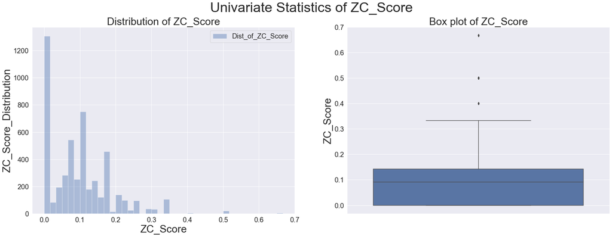

```python
# ZC_Score is a numeric variable. Get distribution and box plot
fig_8 = plt.figure(8, figsize = (30,10))
fig_8.suptitle('Univariate Statistics of ZC_Score')

ax1 = plt.subplot(1,2,1)
sns.distplot(ploan_zcm_df['ZC_Score'], kde = False, label = 'Dist_of_ZC_Score')
ax1.set_title('Distribution of ZC_Score')
ax1.set_ylabel('ZC_Score_Distribution')
ax1.legend()

ax2 = plt.subplot(1,2,2)
sns.boxplot(y = 'ZC_Score', data = ploan_zcm_df)
ax2.set_title('Box plot of ZC_Score')
ax2.set_ylabel('ZC_Score')

plt.show()
```

- **Significant right-skew seen. Box plot indicates a few outliers.**

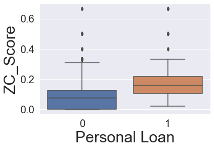

```python
sns.boxplot(x = 'Personal Loan', y = 'ZC_Score', data = ploan_zcm_df)
plt.show()
```

- **The above box plot shows that ZIP Codes with higher ZC_Score have a larger percentage of customers who accepted personal loan. This makes sense since ZC_Score is a direct indication of the percentage of customers who accepted personal loans in each ZIP Code.**
- Hence, it is expected that this feature will have some predictive behavior with respect to customer loan acceptance.</b>

```python
ct_pl_zcf = pd.crosstab(ploan_zcm_df['Personal Loan'], ploan_zcm_df['ZC_Freq'], margins = True)
display(ct_pl_zcf)
print("Percentage of individuals in group G1 and accepted personal loan: \
%0.2f" % ((100 * ct_pl_zcf.iloc[1, 0]) / (ct_pl_zcf.iloc[0, 0] + ct_pl_zcf.iloc[1, 0])))
print("Percentage of individuals in group G2 and accepted personal loan: \
%0.2f" % ((100 * ct_pl_zcf.iloc[1, 1]) / (ct_pl_zcf.iloc[0, 1] + ct_pl_zcf.iloc[1, 1])))
print("Percentage of individuals in group G3 and accepted personal loan: \
%0.2f" % ((100 * ct_pl_zcf.iloc[1, 2]) / (ct_pl_zcf.iloc[0, 2] + ct_pl_zcf.iloc[1, 2])))
print("Percentage of individuals in group G4 and accepted personal loan: \
%0.2f" % ((100 * ct_pl_zcf.iloc[1, 3]) / (ct_pl_zcf.iloc[0, 3] + ct_pl_zcf.iloc[1, 3])))
```

| ZC_Freq Personal Loan | G1 | G2 | G3 | G4 | All |
| --- | --- | --- | --- | --- | --- |
| 0 | 1613 | 1101 | 1028 | 778 | 4520 |
| 1 | 167 | 108 | 127 | 78 | 480 |
| All | 1780 | 1209 | 1155 | 856 | 5000 |

```
Percentage of individuals in group G1 and accepted personal loan: 9.38
Percentage of individuals in group G2 and accepted personal loan: 8.93
Percentage of individuals in group G3 and accepted personal loan: 11.00
Percentage of individuals in group G4 and accepted personal loan: 9.11
```

**From the data above, it seems like there is no major difference in the personal loan acceptance rate between individuals from the four groups.**

This feature is not expected to have significant predictive effect on the customer personal loan acceptance.</b>

# 8 Pairplots

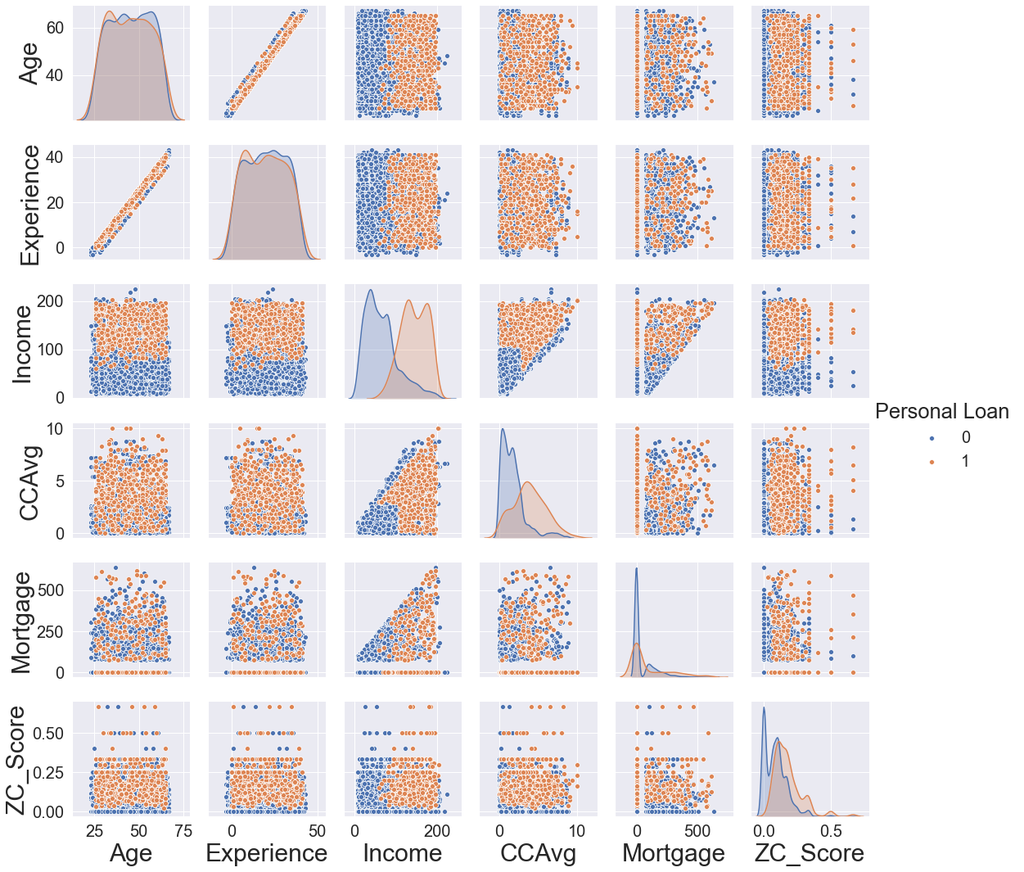

```python
var_list = list(ploan_zcm_df.dtypes.index[ploan_zcm_df.dtypes != 'category'])
sns.pairplot(ploan_zcm_df, vars = var_list, hue = 'Personal Loan', diag_kind='kde')
plt.show()
```

**Observations from pairplots above:**

1. A very strong positive correlation is seen between age and experience.
2. The income rows and columns clearly indicate that customer personal loan acceptance is concentrated at higher incomes. As mentioned earlier, income is expected to have a significant predictive impact on customer personal loan acceptance.
3. There is significant correlation seen between Income and CCAvg also. More particularly, higher CCAvg values tend to be associated with higher incomes.

# 9 Correlation Matrix

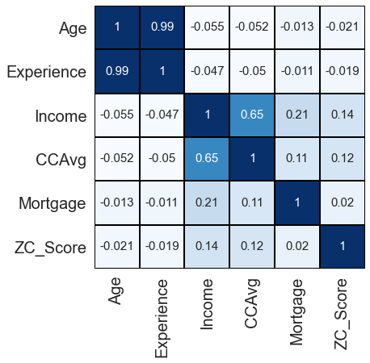

```python
corr_mat = ploan_zcm_df.corr()
plt.figure(figsize = (6,6))
sns.heatmap(corr_mat, annot_kws = {"fontsize": 15}, linewidths = 1,\
            linecolor = 'black', cmap = 'Blues', annot = True ,fmt = '.2g', cbar = False)
plt.show()
```

**Observations from Correlation Matrix:**

1. Age and Experience have a very high positive correlation of 0.99 as seen from the pair plot above.
2. Income vs. CCAvg shows a correlation of 0.65, which is moderately high.

```python
# Drop Experience from feature list since it is highly correlated with Age.
# This is to avoid multicollinearity issues for the linear models.
ploan_zcm_df.drop(columns = 'Experience', inplace = True)
```

# 10 One-Hot Encoding

```python
# One-hot encode all categorical columns with more than two categories
cols_one_hot_enc = ['Family', 'Education', 'ZC_Freq']
pref_one_hot_enc = ['FMS', 'ED', 'ZCF']
ploan_zcm_df = pd.get_dummies(ploan_zcm_df, prefix = pref_one_hot_enc,\
                              columns = cols_one_hot_enc, drop_first = True)
for ind1 in ploan_zcm_df.columns:
    for ind2 in pref_one_hot_enc:
        if (ind2 + "_") in ind1:
            ploan_zcm_df[ind1] = ploan_zcm_df[ind1].astype('category')
display(ploan_zcm_df.head())
```

|  | Age | Income | CCAvg | Mortgage | Personal Loan | Securities Account | CD Account | Online | CreditCard | ZC_Score | FMS_2 | FMS_3 | FMS_4 | ED_2 | ED_3 | ZCF_G2 | ZCF_G3 | ZCF_G4 |
| --- | --- | --- | --- | --- | --- | --- | --- | --- | --- | --- | --- | --- | --- | --- | --- | --- | --- | --- |
| 0 | 25 | 49 | 1.6 | 0 | 0 | 1 | 0 | 0 | 0 | 0.1200 | 0 | 0 | 1 | 0 | 0 | 0 | 1 | 0 |
| 1 | 45 | 34 | 1.5 | 0 | 0 | 1 | 0 | 0 | 0 | 0.1739 | 0 | 1 | 0 | 0 | 0 | 0 | 1 | 0 |
| 2 | 39 | 11 | 1.0 | 0 | 0 | 0 | 0 | 0 | 0 | 0.1124 | 0 | 0 | 0 | 0 | 0 | 0 | 0 | 1 |
| 3 | 35 | 100 | 2.7 | 0 | 0 | 0 | 0 | 0 | 0 | 0.0000 | 0 | 0 | 0 | 1 | 0 | 1 | 0 | 0 |
| 4 | 35 | 45 | 1.0 | 0 | 0 | 0 | 0 | 0 | 1 | 0.0652 | 0 | 0 | 1 | 1 | 0 | 0 | 1 | 0 |

# 11 Generate Train / Test sets

- The dataset will now be split into train and test sets in the ratio 70:30.
- Since the dataset is heaving imbalanced, splitting will be stratified using the output variable to maintain the same class distribution in the train and test sets as it is in the original dataset.

```python
X = ploan_zcm_df.drop(columns = 'Personal Loan')
y = ploan_zcm_df['Personal Loan']

# Generate unscaled train and test datasets
# Training set : test set ratio = 70 : 30
# Since the data set is heavily imbalanced, splitting is stratified with the response variable.
X_train_us, X_test_us, y_train, y_test = train_test_split(X, y, test_size = 0.3,\
                                                          stratify = y, random_state=0)
print("X_train.shape: {}" .format(X_train_us.shape))
print("y_train.shape: {}" .format(y_train.shape))
print("X_test.shape: {}" .format(X_test_us.shape))
print("y_test.shape: {}" .format(y_test.shape))
```

```
X_train.shape: (3500, 17)
y_train.shape: (3500,)
X_test.shape: (1500, 17)
y_test.shape: (1500,)
```

# 12 Normalize numeric features

```python
# Normalize numeric features using the 'norm_num_feat' function defined above
# Here will scale all numeric features using 'MinMaxScaler'. Other scaler options are
# evaluated later.

scal_dict = {0: ['Age', 'Age_Scaled', 'mm_sc'],
             1: ['Income', 'Income_Scaled', 'mm_sc'],
             2: ['CCAvg', 'CCAvg_Scaled', 'mm_sc'],
             3: ['Mortgage', 'Mortgage_Scaled', 'mm_sc'],
             4: ['ZC_Score', 'ZC_Score_Scaled', 'mm_sc']
            }
X_train, X_test = norm_num_feat(X_train_us, X_test_us, scal_dict)
```

# 13 Positive and Negative class summary

```python
# Compute distribution of positive and negative classes in full dataset
TC_PC_FDS = ploan_df['Personal Loan'].value_counts()[1] # True class; Positive Count; Full dataset
TC_NC_FDS = ploan_df['Personal Loan'].count() - TC_PC_FDS # True class; Negative count; Full dataset

# Compute distribution of positive and negative classes in train and test sets
TC_PC_TrS = y_train.value_counts()[1] # True class; Positive Count; Training Data set
TC_NC_TrS = y_train.count() - TC_PC_TrS # True class; Negative count; Training Data set
TC_PC_TeS = y_test.value_counts()[1] # True class; Positive Count; Test Data set
TC_NC_TeS = y_test.count() - TC_PC_TeS # True class; Negative count; Test Data set

print("Full Dataset")
print("================")
print("Number of customers who did not accept personal loan in last campaign: %d (%0.2f %%)"\
      %(TC_NC_FDS, (100 * TC_NC_FDS / (TC_NC_FDS + TC_PC_FDS))))
print("Number of customers who accepted personal loan in last campaign: %d (%0.2f %%)"\
      %(TC_PC_FDS, (100 * TC_PC_FDS / (TC_NC_FDS + TC_PC_FDS))))
print('')

print("Training Set")
print("============")
print("Number of customers who did not accept personal loan in last campaign: %d (%0.2f %%)"\
      %(TC_NC_TrS, (100 * TC_NC_TrS / (TC_NC_TrS + TC_PC_TrS))))
print("Number of customers who accepted personal loan in last campaign: %d (%0.2f %%)"\
      %(TC_PC_TrS, (100 * TC_PC_TrS / (TC_NC_TrS + TC_PC_TrS))))
print('')

print("Test Set")
print("=========")
print("Number of customers who did not accept personal loan in last campaign: %d (%0.2f %%)"\
      %(TC_NC_TeS, (100 * TC_NC_TeS / (TC_NC_TeS + TC_PC_TeS))))
print("Number of customers who accepted personal loan in last campaign: %d (%0.2f %%)"\
      %(TC_PC_TeS, (100 * TC_PC_TeS / (TC_NC_TeS + TC_PC_TeS))))
```

```
Full Dataset
================
Number of customers who did not accept personal loan in last campaign: 4520 (90.40 %)
Number of customers who accepted personal loan in last campaign: 480 (9.60 %)

Training Set
============
Number of customers who did not accept personal loan in last campaign: 3164 (90.40 %)
Number of customers who accepted personal loan in last campaign: 336 (9.60 %)

Test Set
=========
Number of customers who did not accept personal loan in last campaign: 1356 (90.40 %)
Number of customers who accepted personal loan in last campaign: 144 (9.60 %)
```

**The above data indicates that the train and test splits have been done while maintaining the positive to negative class ratio.**

# 14 Models - Fit and Evaluate

- In this section, we fit all the models defined in **Init Classifier** above. Multiple metrics evaluated on the training and test sets are printed. Next, confusion matrices, ROC plots and precision - recall plots are plotted.
- Summary of all models is provided after the precision - recall plots.

## 14.1 Fit and Evaluate

```python
# Define list of classifiers to evaluate
clfs = clf_define()

# Obtain list of columns that are categorical and numeric
nb_bin_cols = list(X_train.dtypes.index[X_train.dtypes == 'category'])
nb_num_cols = list(X_train.dtypes.index[X_train.dtypes != 'category'])

# List of output parameters that will be evaluated for each classifier
# Classifier Accuracy, Precision, Recall, F1-Score
# AUC (Area Under ROC curve)
# APS (Average Precsion Score, area under precision - recall curve)
param_names = ['Class_Acc(%)', 'Precision', 'Recall', 'F1-Score', 'AUC', 'APS']

bnb, gnb, _, _ = model_fit_eval(clfs, param_names, X_train, y_train, X_test, y_test,\
                          nb_bin_cols, nb_num_cols, print_train_res = True, print_test_res = True)
```

```
Summary of all models on training set
=====================================
```

|  | Class_Acc(%) | Precision | Recall | F1-Score | AUC | APS |
| --- | --- | --- | --- | --- | --- | --- |
| Dummy_Classifier_With_Most_Frequent_Strategy | 90.4000 | NaN | 0.0000 | 0.0000 | 0.5000 | 0.0960 |
| Logistic_Regression_Without_Class_Weights | 96.4286 | 0.9414 | 0.6696 | 0.7826 | 0.9742 | 0.8866 |
| Logistic_Regression_With_Balanced_Class_Weights | 91.7429 | 0.5412 | 0.9196 | 0.6814 | 0.9759 | 0.8795 |
| Mixed_Naive_Bayes | 94.7143 | 0.7938 | 0.6071 | 0.6880 | 0.9567 | 0.7466 |
| K_Nearest_Neighbors with 5 neighbors | 94.4571 | 0.9671 | 0.4375 | 0.6025 | 0.9885 | 0.8637 |
| K_Nearest_Neighbors with 12 neighbors | 91.0857 | 1.0000 | 0.0714 | 0.1333 | 0.9693 | 0.7625 |
| Linear_Support_Vector_Classifier | 91.8286 | 0.5440 | 0.9196 | 0.6836 | 0.9759 | 0.8794 |
| SVM_With_Poly_Kernel | 98.4857 | 0.8714 | 0.9881 | 0.9261 | 0.9979 | 0.9806 |
| SVM_With_RBF_Kernel | 98.2286 | 0.8531 | 0.9851 | 0.9144 | 0.9972 | 0.9848 |
| Random_Forest_Classifer_With_100_Trees | 100.0000 | 1.0000 | 1.0000 | 1.0000 | 1.0000 | 1.0000 |
| Gradient_Boosting_Trees_Classifier_with_100_Trees | 99.5143 | 0.9938 | 0.9554 | 0.9742 | 0.9996 | 0.9969 |

```
Summary of all models on test set
=====================================
```

|  | Class_Acc(%) | Precision | Recall | F1-Score | AUC | APS |
| --- | --- | --- | --- | --- | --- | --- |
| Dummy_Classifier_With_Most_Frequent_Strategy | 90.4000 | NaN | 0.0000 | 0.0000 | 0.5000 | 0.0960 |
| Logistic_Regression_Without_Class_Weights | 95.8000 | 0.9091 | 0.6250 | 0.7407 | 0.9698 | 0.8725 |
| Logistic_Regression_With_Balanced_Class_Weights | 91.7333 | 0.5407 | 0.9236 | 0.6821 | 0.9732 | 0.8715 |
| Mixed_Naive_Bayes | 94.7333 | 0.8351 | 0.5625 | 0.6722 | 0.9636 | 0.7860 |
| K_Nearest_Neighbors with 5 neighbors | 93.4667 | 0.9600 | 0.3333 | 0.4948 | 0.8600 | 0.6291 |
| K_Nearest_Neighbors with 12 neighbors | 91.9333 | 1.0000 | 0.1597 | 0.2754 | 0.8957 | 0.6109 |
| Linear_Support_Vector_Classifier | 91.4667 | 0.5320 | 0.9236 | 0.6751 | 0.9733 | 0.8717 |
| SVM_With_Poly_Kernel | 97.0000 | 0.8000 | 0.9167 | 0.8544 | 0.9866 | 0.9367 |
| SVM_With_RBF_Kernel | 97.6667 | 0.8303 | 0.9514 | 0.8867 | 0.9880 | 0.9542 |
| Random_Forest_Classifer_With_100_Trees | 98.7333 | 0.9771 | 0.8889 | 0.9309 | 0.9973 | 0.9821 |
| Gradient_Boosting_Trees_Classifier_with_100_Trees | 98.9333 | 0.9848 | 0.9028 | 0.9420 | 0.9962 | 0.9795 |

## 14.2 Confustion Matrices - Test Set

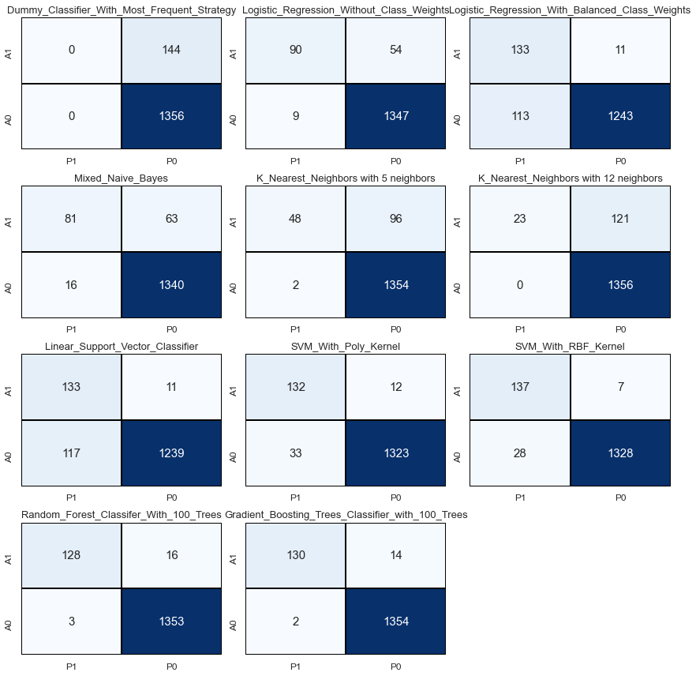

```python
plot_conf_mat(clfs, X_test, y_test, bnb, gnb, nb_bin_cols, nb_num_cols, 3)
```

## 14.3 ROC plots - Test Set

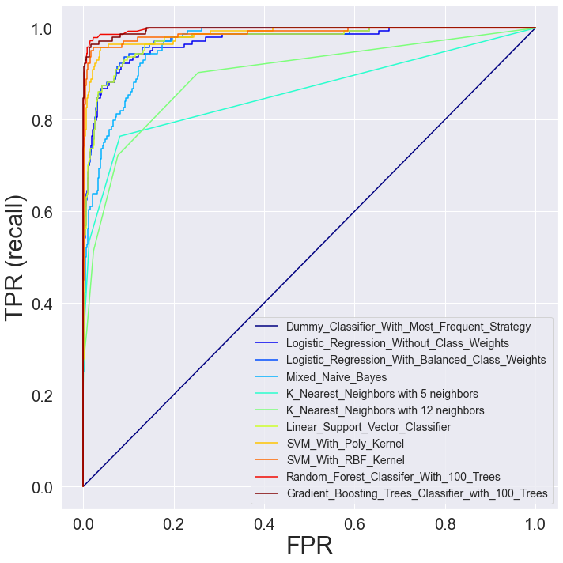

```python
plot_roc_curves(clfs, X_test, y_test, bnb, gnb, nb_bin_cols, nb_num_cols)
```

## 14.4 Precision - Recall plots - Test Set

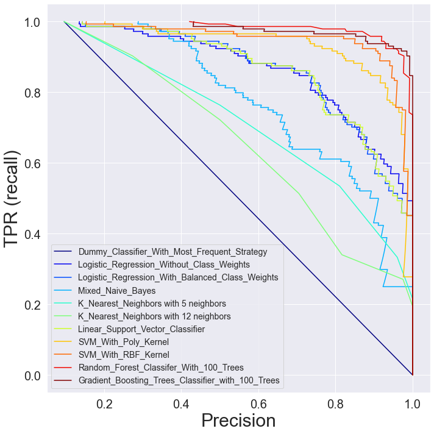

```python
plot_prec_rec_curves(clfs, X_test, y_test, bnb, gnb, nb_bin_cols, nb_num_cols)
```

## 14.5 Summary of all models (based on test set results)

- **Dummy_Classifier:** As expected, this classifier provides a high classification accuracy (because of the imbalanced dataset but it has **zero recall**. Confusion matrix (CM) on test set reveals that no positives have been identified as expected. True Positives (TP) = False Positives (FP) = 0. There are 144 False Negative (FN) predictions. AUC = 0.5 as expected.
- **Logistic_Regression_With_Default_Settings:** This classifier shows improved classification accuracy but has very poor recall of only 63%. CM indicates that only 90 out of 144 actual positives have been predicted as belonging to the positive class which explains the poor recall. These results, however use the default probability threshold of > 0.5 to classify a sample as belonging to the positive class. By lowering this prediction threshold, we should be able to improve the number of TP's significantly and subsequently recall as well. However, this will worsen the FPR and Precision. Depending on the cost associated with falsely classifying a negative-class sample as belonging to the positive class, this may be okay from a business perspective. AUC score of 0.97 indicates that the recall can be significantly improved.
- **Logistic_Regression_With_Balanced_Class_Weigths:** Since the dataset is heavily skewed, using balanced class weights should improve the recall performance of the classifier. As expected, recall performance of this classifier is much better at 93%. CM indicates that 133 out of 144 actual positives have been correctly classified! (as compared to only 90 out of 144 with default logistic regression). There are only 11 FN's now. However, this comes as the cost of larger FP's (because the classifier is overall classifying more samples as positive). Subsequently, precision and classification accuracy are both lower than for 'logistic regression without class weights'. AUC score is now 0.97 which is only marginally better than logistic regression without class weights. If we adjust the probability thresholds carefully before making predictions, then we can expect that both versions of logistic regression (with and without class weights) will yield similar TPR's.
- **Mixed_Naive_Bayes:** This classifier shows very poor recall performance since it makes strong assumptions about the class-conditional independence of the input features. Only 81 out of 144 actual positives are correctly classified as positive. However, AUC score is still high at 0.96, and we should be able to get much better TPR by adjusting the prediction probability threshold.
- **KNN classifier:** This classifier is run for two values of K (number of nearest neighbors): K = 5 and K = 12. Both versions have very poor recall performance and K = 12 is worse than K = 5. Since the dataset output is heavily skewed towards the negative class, any test sample that we take is likely to see more neighboring training samples from the negative class as compared to the positive class because of which most of the samples will end up getting classified into the negative class. With K = 5, only 48 out of 144 actual positives are correctly classified as positive. Also, there are only 2 FP's indicating that the KNN classifier is heavily biased towards making negative class predictions. WIth K = 12, this effect is even more amplified. There are only 23 TP's now and zero FP's. K = 12 however, provides the best AUC performance (checked by doing a hyperparameter search for K in the range of 1 to 20 and using test set AUC as the metric to choose K). Overall, KNN has poorer AUC score than Logistic Regression / Mixed Naive Bayes.
- **Linear Support Vector Classifier:** The performance of this classifier with balanced class weights is very very close to the performance of the logistic regression classifier with balanced class weights. This is expected since both these classifiers can produce only linear decision boundaries.
- **SVM with Poly and RBF Kernel:** Both the non-linear SVM classifiers perform similar to each other and the recall / AUC performance is only marginally better than the linear classifiers. However, both these classifiers are able to achieve higher precision, lower classification error rate, higher F1-score and higher APS than the linear classifiers indicating that these two non-linear classifiers are able to do well on classifying both the positive and negative classes. This in turn indicates that the actual decision boundary is non-linear and both the non-linear SVM classifiers are able to approximate the non-linear decision boundary better than the linear classifiers.
- **Random Forest and Gradient Boosted Classifiers:** Finally, both the ensemble methods show slightly poorer recall (with default thresholds) than the SVM models but have the best AUC, APS, classification accuracy, F1-scores of all the models. With properly adjusted prediction thresholds, it is expected that these two classifiers will perform the best of the lot.

## 14.6 Confustion Matrices - Test Set - Best thresholds

- In this section, we will use the 'pr_conf_mat_def_best' function to find the point on the ROC curve that is closest to the (TPR = 1, FPR = 0) point for each classifier and identify the corresponding threshold. We will then use this threshold as the prediction threshold, obtain predictions on the test set and print confusion matrices with these new thresholds to see the best performance we can get from each classifier.

```python
pr_conf_mat_def_best(clfs, X_test, y_test, bnb, gnb, nb_bin_cols, nb_num_cols)
```

|  | TP_Def | FN_Def | FP_Def | TN_Def | Best_Thresh | TP_Best | FN_Best | FP_Best | TN_Best |
| --- | --- | --- | --- | --- | --- | --- | --- | --- | --- |
| Dummy_Classifier_With_Most_Frequent_Strategy | 0.0 | 144.0 | 0.0 | 1356.0 | 1.0000 | 0.0 | 144.0 | 0.0 | 1356.0 |
| Logistic_Regression_Without_Class_Weights | 90.0 | 54.0 | 9.0 | 1347.0 | 0.1314 | 133.0 | 11.0 | 118.0 | 1238.0 |
| Logistic_Regression_With_Balanced_Class_Weights | 133.0 | 11.0 | 113.0 | 1243.0 | 0.5146 | 133.0 | 11.0 | 108.0 | 1248.0 |
| Mixed_Naive_Bayes | 81.0 | 63.0 | 16.0 | 1340.0 | 0.0547 | 133.0 | 11.0 | 170.0 | 1186.0 |
| K_Nearest_Neighbors with 5 neighbors | 48.0 | 96.0 | 2.0 | 1354.0 | 0.2000 | 110.0 | 34.0 | 110.0 | 1246.0 |
| K_Nearest_Neighbors with 12 neighbors | 23.0 | 121.0 | 0.0 | 1356.0 | 0.0833 | 130.0 | 14.0 | 345.0 | 1011.0 |
| Linear_Support_Vector_Classifier | 133.0 | 11.0 | 117.0 | 1239.0 | 0.0417 | 132.0 | 12.0 | 106.0 | 1250.0 |
| SVM_With_Poly_Kernel | 132.0 | 12.0 | 33.0 | 1323.0 | -0.6040 | 138.0 | 6.0 | 52.0 | 1304.0 |
| SVM_With_RBF_Kernel | 137.0 | 7.0 | 28.0 | 1328.0 | -0.0200 | 138.0 | 6.0 | 30.0 | 1326.0 |
| Random_Forest_Classifer_With_100_Trees | 128.0 | 16.0 | 3.0 | 1353.0 | 0.1700 | 141.0 | 3.0 | 30.0 | 1326.0 |
| Gradient_Boosting_Trees_Classifier_with_100_Trees | 130.0 | 14.0 | 2.0 | 1354.0 | 0.1099 | 139.0 | 5.0 | 24.0 | 1332.0 |

**Summary of above table**

- In the table above, TP_Def, FN_Def, FP_Def, TN_Def refer to TP, FN, FP, TN with default thresholds (0.5 for probability threshold and 0 for decision function thresholds). TP_Best, FN_Best, FP_Best, TN_Best refer to TP, FN, FP, TN with the best threshold chosen based on the test set ROC curve.
- **Note:** Since we are using the test set itself to identify the best threshold, we are technically overfitting to the test set. Ideally, this value should be obtained using cross-validation.
- From the table above, we can see that most of the classifiers show a significant increase in the number of true positives and a significant decrease in the number of false negatives, which increase recall (TPR) as expected. However, this comes at the cost of an increase in the number of FP's which increases FPR and reduces precision.
- For the linear classifiers with balanced class weights, TP/FN didn't change with the best threshold but the number of FP's reduced leading to better classification.
- Logistic regression with and without balanced class weights now show the same number of TP and FN as commented earlier. However, the balanced class weight version has lower FP's which still makes it a better classifier.
- Finally, the ensemble methods (Random Forest and Gradient Boosting Trees) show the best recall performance followed by the SVM classifiers.

## 14.7 Feature Importances

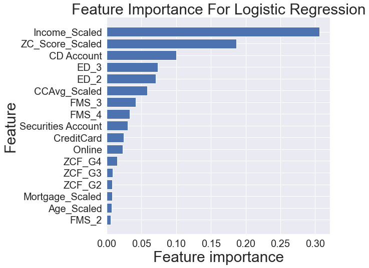

```python
# Feature importances for logistic regression with balanced class weights
# Since all the features are scaled to [0, 1] range, we can use the coefficients from
# the logistic regression classifier to assess the feature importances.
# The feature importances here are obtained by dividing the absolute value of each coefficient
# by the sum of the absolute values of all coefficients. This provides the relative importance
# of each feature.
ind = 2
clfs[ind][0].coef_
clf_feat_imp = np.squeeze(np.abs(clfs[ind][0].coef_) / np.sum(np.abs(clfs[ind][0].coef_)))
feat_imp_df = pd.DataFrame(clf_feat_imp, columns = ['Feat_Imp'], index = X_train.columns)
feat_imp_df.sort_values(by = 'Feat_Imp', inplace = True)
plt.figure(figsize = (8, 8))
plt.barh(feat_imp_df.index, feat_imp_df['Feat_Imp'] , align='center')
plt.xlabel("Feature importance")
plt.ylabel("Feature")
plt.title("Feature Importance For Logistic Regression")
plt.show()
```

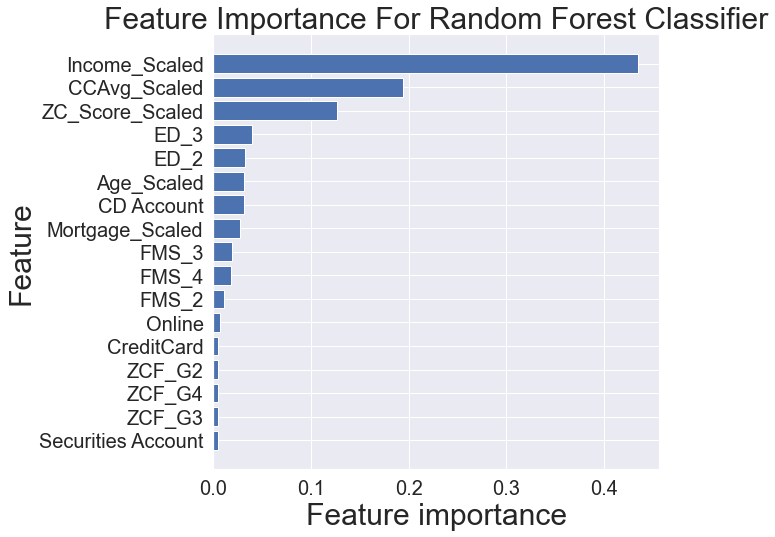

```python
# Random Forest Classifier
ind = 9
clf_feat_imp = clfs[ind][0].feature_importances_
feat_imp_df = pd.DataFrame(clf_feat_imp, columns = ['Feat_Imp'], index = X_train.columns)
feat_imp_df.sort_values(by = 'Feat_Imp', inplace = True)
plt.figure(figsize = (8, 8))
plt.barh(feat_imp_df.index, feat_imp_df['Feat_Imp'] , align='center')
plt.xlabel("Feature importance")
plt.ylabel("Feature")
plt.title("Feature Importance For Random Forest Classifier")
plt.show()
```

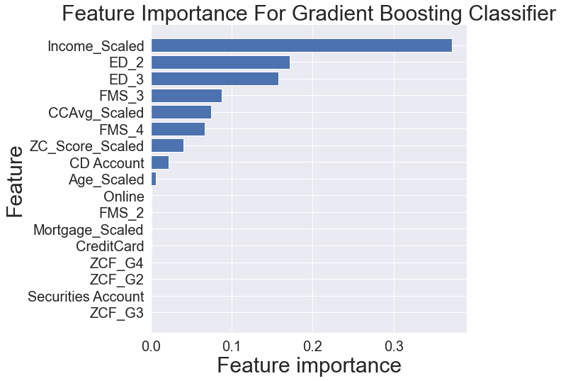

```python
# Gradient Boosting Classifier
ind = 10
clf_feat_imp = clfs[ind][0].feature_importances_
feat_imp_df = pd.DataFrame(clf_feat_imp, columns = ['Feat_Imp'], index = X_train.columns)
feat_imp_df.sort_values(by = 'Feat_Imp', inplace = True)
plt.figure(figsize = (8, 8))
plt.barh(feat_imp_df.index, feat_imp_df['Feat_Imp'] , align='center')
plt.xlabel("Feature importance")
plt.ylabel("Feature")
plt.title("Feature Importance For Gradient Boosting Classifier")
plt.show()
```

**All classifiers identify Income as the most important feature.**

CCAvg, ED_2, ED_3, ZC_Score are also consistently identified as important features by all the classifiers.</b>

# 15 Hyperparameter Search

## 15.1 KNN: n_neighbors

|  | Best_Value_Classifier | Best_Value |
| --- | --- | --- |
| Class_Acc(%) | KNN_num_neighbor_1 | 94.4667 |
| F1-Score | KNN_num_neighbor_1 | 0.6640 |
| AUC | KNN_num_neighbor_12 | 0.8957 |
| APS | KNN_num_neighbor_8 | 0.6417 |

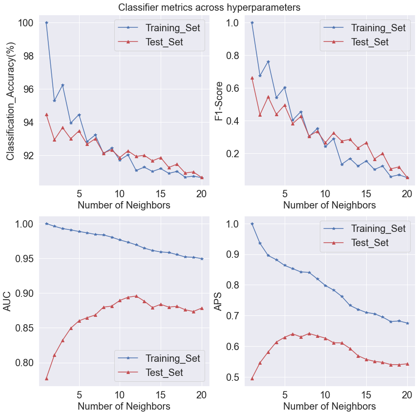

```python
clf_type = 'KNN' # Type of classifier
var1 = list(range(1, 21, 1)) # List of n_neighbors to iterate over
var2 = None

ms_train, ms_test = hyper_par_search(clf_type, var1, var2, param_names, X_train, y_train,\
                     X_test, y_test, print_train_res = False, print_test_res = False,\
                                     plot_res = True)
```

**A sweep of K (number of neighbors) from 1 to 20 for the KNN classifier shows that AUC peaks at K = 12.**

## 15.2 Logistic_Regression: Regularization parameter

|  | Best_Value_Classifier | Best_Value |
| --- | --- | --- |
| Class_Acc(%) | LogReg_With_Bal_Cl_Weights_C_1.995 | 91.7333 |
| F1-Score | LogReg_With_Bal_Cl_Weights_C_1.995 | 0.6821 |
| AUC | LogReg_With_Bal_Cl_Weights_C_10.000 | 0.9732 |
| APS | LogReg_With_Bal_Cl_Weights_C_10.000 | 0.8721 |

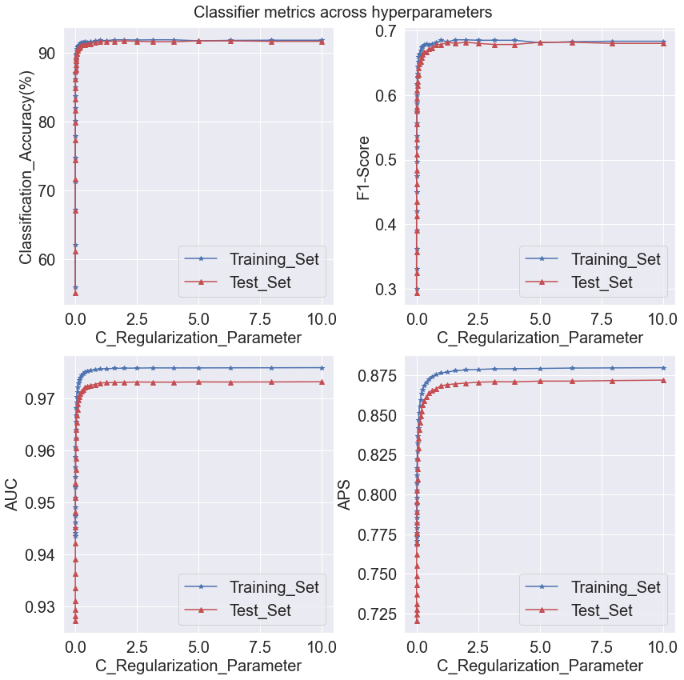

```python
clf_type = 'linear' # Type of classifier
var1 = list(np.power(10, np.linspace(-3, 1, 41))) # Values for C - regularization parameter
var2 = None

ms_train, ms_test = hyper_par_search(clf_type, var1, var2, param_names, X_train, y_train,\
                     X_test, y_test, print_train_res = False, print_test_res = False,\
                                     plot_res = True)
```

**Here the regularization parameter, C is swept from 1e-3 to 10 in logarithmic steps with 10 points per decade. AUC value is highest for C = 10.**

## 15.3 SVM with RBF Kernel: C and gamma

```python
# Coarse search
# C is swept over the values [1, 10, 100, 1000]
# gamma is swept over the values [0.01, 0.1, 1, 10]
clf_type = 'SVM_RBF' # Type of classifier
var1 = list(np.power(10, np.linspace(0, 3, 4))) # Values for C - regularization parameter
var2 = list(np.power(10, np.linspace(-2, 1, 4))) # Values for gamma

ms_train, ms_test = hyper_par_search(clf_type, var1, var2, param_names, X_train, y_train,\
                     X_test, y_test, print_train_res = False, print_test_res = False,\
                                     plot_res = False)
```

|  | Best_Value_Classifier | Best_Value |
| --- | --- | --- |
| Class_Acc(%) | SVM_RBF_C_100.000_gamma_0.100 | 97.8667 |
| F1-Score | SVM_RBF_C_100.000_gamma_0.100 | 0.8926 |
| AUC | SVM_RBF_C_1000.000_gamma_0.010 | 0.9864 |
| APS | SVM_RBF_C_10.000_gamma_0.100 | 0.9590 |

**Based on coarse search results, we will set C = 1000 and search over gamma in the range (0.01, 1).**

```python
# Fine Search
# C is fixed at 1000.
# Gamma is swept over the values 0.01 to 1 in logarithmic steps with 10 points per decade.
clf_type = 'SVM_RBF' # Type of classifier
var1 = [1000] # Values for C - regularization parameter
var2 = list(np.power(10, np.linspace(-2, 0, 21))) # Values for gamma

ms_train, ms_test = hyper_par_search(clf_type, var1, var2, param_names, X_train, y_train,\
                     X_test, y_test, print_train_res = False, print_test_res = False,\
                                     plot_res = False)
```

|  | Best_Value_Classifier | Best_Value |
| --- | --- | --- |
| Class_Acc(%) | SVM_RBF_C_1000.000_gamma_0.032 | 97.8000 |
| F1-Score | SVM_RBF_C_1000.000_gamma_0.032 | 0.8911 |
| AUC | SVM_RBF_C_1000.000_gamma_0.025 | 0.9881 |
| APS | SVM_RBF_C_1000.000_gamma_0.010 | 0.9586 |

**Best AUC is obtained for C = 1000 and gamma = 0.025.**

## 15.4 SVM with Polynomial Kernel: degree and gamma

```python
# Coarse search
# Degree is swept from 1 to 5.
# gamma is swept over the values [0.01, 0.1, 1]
clf_type = 'SVM_Poly' # Type of classifier
var1 = list(range(1, 6, 1)) # Values for polynomial degree
var2 = list(np.power(10, np.linspace(-2, 0, 3))) # Values for gamma
ms_train, ms_test = hyper_par_search(clf_type, var1, var2, param_names, X_train, y_train,\
                     X_test, y_test, print_train_res = False, print_test_res = False,\
                                     plot_res = False)
```

|  | Best_Value_Classifier | Best_Value |
| --- | --- | --- |
| Class_Acc(%) | SVM_Poly_deg_5.000_gamma_0.100 | 97.8667 |
| F1-Score | SVM_Poly_deg_5.000_gamma_0.100 | 0.8857 |
| AUC | SVM_Poly_deg_2.000_gamma_0.100 | 0.9863 |
| APS | SVM_Poly_deg_2.000_gamma_0.010 | 0.9572 |

**Based on coarse search results, we will set degree = 2 and search over gamma in the range (0.01, 1).**

```python
# Fine search
# Degree is fixed at 2.
# Gamma is swept over the values 0.01 to 1 in logarithmic steps with 10 points per decade.
clf_type = 'SVM_Poly' # Type of classifier
var1 = [2] # Values for polynomial degree
var2 = list(np.power(10, np.linspace(-2, 0, 21))) # Values for gamma
ms_train, ms_test = hyper_par_search(clf_type, var1, var2, param_names, X_train, y_train,\
                     X_test, y_test, print_train_res = False, print_test_res = False,\
                                     plot_res = False)
```

|  | Best_Value_Classifier | Best_Value |
| --- | --- | --- |
| Class_Acc(%) | SVM_Poly_deg_2.000_gamma_0.040 | 97.4000 |
| F1-Score | SVM_Poly_deg_2.000_gamma_0.040 | 0.8754 |
| AUC | SVM_Poly_deg_2.000_gamma_0.158 | 0.9866 |
| APS | SVM_Poly_deg_2.000_gamma_0.010 | 0.9572 |

**Best AUC is obtained for degree = 2 and gamma = 0.158.**

# 16 Miscellaneous

- In this section, we will try out other ways to map the input features and compare them with the results obtained above.

## 16.1 One-hot encode entire Zip Code List

- See what happens if entire Zip Code List is one-hot encoded instead of using ZC_Freq and ZC_Score

```python
ploan_trial_df = ploan_df.copy()
ploan_trial_df.drop(columns = 'Experience', inplace = True)
cols_one_hot_enc = ['Family', 'Education', 'ZIP Code']
pref_one_hot_enc = ['FMS', 'ED', 'ZC']
ploan_trial_df = pd.get_dummies(ploan_trial_df, prefix = pref_one_hot_enc,\
                              columns = cols_one_hot_enc, drop_first = True)

Xt = ploan_trial_df.drop(columns = 'Personal Loan')
yt = ploan_trial_df['Personal Loan']
Xt_train_us, Xt_test_us, yt_train, yt_test = train_test_split(Xt, yt, test_size = 0.3,\
                                                          stratify = yt, random_state=0)
scal_dict = {0: ['Age', 'Age_Scaled', 'mm_sc'],
             1: ['Income', 'Income_Scaled', 'mm_sc'],
             2: ['CCAvg', 'CCAvg_Scaled', 'mm_sc'],
             3: ['Mortgage', 'Mortgage_Scaled', 'mm_sc'],
            }
Xt_train, Xt_test = norm_num_feat(Xt_train_us, Xt_test_us, scal_dict)

# Use smaller list of classifiers to compare
clfs_small = clf_small_define()
param_names = ['Class_Acc(%)', 'Precision', 'Recall', 'F1-Score', 'AUC', 'APS']
print("Original Mapping of ZIP Code")
_, _, _, _ = model_fit_eval(clfs_small, param_names, X_train, y_train, X_test, y_test,\
                          None, None, False, True)
print("New Mapping of ZIP Code")
_, _, _, _ = model_fit_eval(clfs_small, param_names, Xt_train, yt_train, Xt_test, yt_test,\
                          None, None, False, True)
```

```
Original Mapping of ZIP Code
Summary of all models on test set
=====================================
```

|  | Class_Acc(%) | Precision | Recall | F1-Score | AUC | APS |
| --- | --- | --- | --- | --- | --- | --- |
| SVM_With_Poly_Kernel | 97.3333 | 0.8133 | 0.9375 | 0.8710 | 0.9856 | 0.9477 |
| SVM_With_RBF_Kernel | 97.6667 | 0.8303 | 0.9514 | 0.8867 | 0.9880 | 0.9542 |
| Random_Forest_Classifer_With_100_Trees | 98.7333 | 0.9771 | 0.8889 | 0.9309 | 0.9973 | 0.9821 |
| Gradient_Boosting_Trees_Classifier_with_100_Trees | 98.9333 | 0.9848 | 0.9028 | 0.9420 | 0.9962 | 0.9795 |

```
New Mapping of ZIP Code
Summary of all models on test set
=====================================
```

|  | Class_Acc(%) | Precision | Recall | F1-Score | AUC | APS |
| --- | --- | --- | --- | --- | --- | --- |
| SVM_With_Poly_Kernel | 96.8000 | 0.8288 | 0.8403 | 0.8345 | 0.9674 | 0.8974 |
| SVM_With_RBF_Kernel | 96.6667 | 0.8219 | 0.8333 | 0.8276 | 0.9680 | 0.8880 |
| Random_Forest_Classifer_With_100_Trees | 98.1333 | 1.0000 | 0.8056 | 0.8923 | 0.9949 | 0.9736 |
| Gradient_Boosting_Trees_Classifier_with_100_Trees | 98.4667 | 0.9840 | 0.8542 | 0.9145 | 0.9932 | 0.9677 |

**Summary: Recall with new mapping of ZIP Code and default thresholds is poorer but AUC is almost same between both the versions.**

## 16.2 Family treated as numeric

- See what happens if family is treated as a numeric variable instead of categorical variable.

```python
zc_bins = [0, 10, 20, 50, 200]
zc_bin_labels = ['G1', 'G2', 'G3', 'G4']
ploan_trial_df = zip_code_mapper(ploan_df, 'ZIP Code', 'ZC_Freq', zc_bins, zc_bin_labels,\
                               'Personal Loan', 'ZC_Score')
ploan_trial_df.drop(columns = 'Experience', inplace = True)

cols_one_hot_enc = ['Education', 'ZC_Freq']
pref_one_hot_enc = ['ED', 'ZCF']
ploan_trial_df = pd.get_dummies(ploan_trial_df, prefix = pref_one_hot_enc,\
                              columns = cols_one_hot_enc, drop_first = True)
for ind1 in ploan_trial_df.columns:
    for ind2 in pref_one_hot_enc:
        if (ind2 + "_") in ind1:
            ploan_trial_df[ind1] = ploan_trial_df[ind1].astype('category')

Xt = ploan_trial_df.drop(columns = 'Personal Loan')
yt = ploan_trial_df['Personal Loan']
Xt_train_us, Xt_test_us, yt_train, yt_test = train_test_split(Xt, yt, test_size = 0.3,\
                                                          stratify = yt, random_state=0)
scal_dict = {0: ['Age', 'Age_Scaled', 'mm_sc'],
             1: ['Income', 'Income_Scaled', 'mm_sc'],
             2: ['CCAvg', 'CCAvg_Scaled', 'mm_sc'],
             3: ['Mortgage', 'Mortgage_Scaled', 'mm_sc'],
             4: ['ZC_Score', 'ZC_Score_Scaled', 'mm_sc'],
             5: ['Family', 'Family_Scaled', 'mm_sc']
            }
Xt_train, Xt_test = norm_num_feat(Xt_train_us, Xt_test_us, scal_dict)

# Use full list of classifiers to compare
clfst = clf_define()
nbt_bin_cols = list(Xt_train.dtypes.index[Xt_train.dtypes == 'category'])
nbt_num_cols = list(Xt_train.dtypes.index[Xt_train.dtypes != 'category'])
param_names = ['Class_Acc(%)', 'Precision', 'Recall', 'F1-Score', 'AUC', 'APS']
print("Original Mapping of Family")
_, _, _, _ = model_fit_eval(clfst, param_names, X_train, y_train, X_test, y_test,\
                          nb_bin_cols, nb_num_cols, False, True)
print("New Mapping of Family")
bnbt, gnbt, _, _ = model_fit_eval(clfst, param_names, Xt_train, yt_train, Xt_test, yt_test,\
                          nbt_bin_cols, nbt_num_cols, False, True)
```

```
Original Mapping of Family
```

```
Summary of all models on test set
=====================================
```

|  | Class_Acc(%) | Precision | Recall | F1-Score | AUC | APS |
| --- | --- | --- | --- | --- | --- | --- |
| Dummy_Classifier_With_Most_Frequent_Strategy | 90.4000 | NaN | 0.0000 | 0.0000 | 0.5000 | 0.0960 |
| Logistic_Regression_Without_Class_Weights | 95.8000 | 0.9091 | 0.6250 | 0.7407 | 0.9698 | 0.8725 |
| Logistic_Regression_With_Balanced_Class_Weights | 91.7333 | 0.5407 | 0.9236 | 0.6821 | 0.9732 | 0.8715 |
| Mixed_Naive_Bayes | 94.7333 | 0.8351 | 0.5625 | 0.6722 | 0.9636 | 0.7860 |
| K_Nearest_Neighbors with 5 neighbors | 93.4667 | 0.9600 | 0.3333 | 0.4948 | 0.8600 | 0.6291 |
| K_Nearest_Neighbors with 12 neighbors | 91.9333 | 1.0000 | 0.1597 | 0.2754 | 0.8957 | 0.6109 |
| Linear_Support_Vector_Classifier | 91.4667 | 0.5320 | 0.9236 | 0.6751 | 0.9733 | 0.8717 |
| SVM_With_Poly_Kernel | 97.0000 | 0.8000 | 0.9167 | 0.8544 | 0.9866 | 0.9367 |
| SVM_With_RBF_Kernel | 97.6667 | 0.8303 | 0.9514 | 0.8867 | 0.9880 | 0.9542 |
| Random_Forest_Classifer_With_100_Trees | 98.7333 | 0.9771 | 0.8889 | 0.9309 | 0.9973 | 0.9821 |
| Gradient_Boosting_Trees_Classifier_with_100_Trees | 98.9333 | 0.9848 | 0.9028 | 0.9420 | 0.9962 | 0.9795 |

```
New Mapping of Family
```

```
Summary of all models on test set
=====================================
```

|  | Class_Acc(%) | Precision | Recall | F1-Score | AUC | APS |
| --- | --- | --- | --- | --- | --- | --- |
| Dummy_Classifier_With_Most_Frequent_Strategy | 90.4000 | NaN | 0.0000 | 0.0000 | 0.5000 | 0.0960 |
| Logistic_Regression_Without_Class_Weights | 96.3333 | 0.9495 | 0.6528 | 0.7737 | 0.9711 | 0.8779 |
| Logistic_Regression_With_Balanced_Class_Weights | 90.9333 | 0.5154 | 0.9306 | 0.6634 | 0.9735 | 0.8695 |
| Mixed_Naive_Bayes | 93.8667 | 0.7000 | 0.6319 | 0.6642 | 0.9611 | 0.7629 |
| K_Nearest_Neighbors with 5 neighbors | 94.0000 | 0.8750 | 0.4375 | 0.5833 | 0.8843 | 0.6809 |
| K_Nearest_Neighbors with 12 neighbors | 92.7333 | 1.0000 | 0.2431 | 0.3911 | 0.9237 | 0.7224 |
| Linear_Support_Vector_Classifier | 90.7333 | 0.5095 | 0.9306 | 0.6585 | 0.9735 | 0.8706 |
| SVM_With_Poly_Kernel | 97.0000 | 0.7964 | 0.9236 | 0.8553 | 0.9832 | 0.9371 |
| SVM_With_RBF_Kernel | 97.2000 | 0.7931 | 0.9583 | 0.8679 | 0.9880 | 0.9579 |
| Random_Forest_Classifer_With_100_Trees | 98.8000 | 0.9922 | 0.8819 | 0.9338 | 0.9966 | 0.9813 |
| Gradient_Boosting_Trees_Classifier_with_100_Trees | 98.7333 | 0.9562 | 0.9097 | 0.9324 | 0.9975 | 0.9833 |

**Summary: AUC is almost same between the two versions.**

## 16.3 Log-transform Income and CCAvg

- Since Income and CCAvg have significant right-skewed distributions, lets try log transform of these variables and see if there is any difference in performance.

```python
zc_bins = [0, 10, 20, 50, 200]
zc_bin_labels = ['G1', 'G2', 'G3', 'G4']
ploan_trial_df = zip_code_mapper(ploan_df, 'ZIP Code', 'ZC_Freq', zc_bins, zc_bin_labels,\
                               'Personal Loan', 'ZC_Score')
ploan_trial_df.drop(columns = 'Experience', inplace = True)

cols_one_hot_enc = ['Family', 'Education', 'ZC_Freq']
pref_one_hot_enc = ['FMS', 'ED', 'ZCF']
ploan_trial_df = pd.get_dummies(ploan_trial_df, prefix = pref_one_hot_enc,\
                              columns = cols_one_hot_enc, drop_first = True)

Xt = ploan_trial_df.drop(columns = 'Personal Loan')
yt = ploan_trial_df['Personal Loan']

Xt['Income'] = np.log(Xt['Income'])
Xt['CCAvg'] = np.log(Xt['CCAvg'] + 0.1) # Add 0.1 to avoid log(zero)

Xt_train_us, Xt_test_us, yt_train, yt_test = train_test_split(Xt, yt, test_size = 0.3,\
                                                          stratify = yt, random_state=0)
scal_dict = {0: ['Age', 'Age_Scaled', 'mm_sc'],
             1: ['Income', 'Income_Scaled', 'mm_sc'],
             2: ['CCAvg', 'CCAvg_Scaled', 'mm_sc'],
             3: ['Mortgage', 'Mortgage_Scaled', 'mm_sc'],
             4: ['ZC_Score', 'ZC_Score_Scaled', 'mm_sc']
            }
Xt_train, Xt_test = norm_num_feat(Xt_train_us, Xt_test_us, scal_dict)

# Use full list of classifiers to compare
clfst = clf_define()
nbt_bin_cols = list(Xt_train.dtypes.index[Xt_train.dtypes == 'category'])
nbt_num_cols = list(Xt_train.dtypes.index[Xt_train.dtypes != 'category'])
param_names = ['Class_Acc(%)', 'Precision', 'Recall', 'F1-Score', 'AUC', 'APS']
print("Income / CCAvg used as it is:")
_, _, _, _ = model_fit_eval(clfst, param_names, X_train, y_train, X_test, y_test,\
                          nb_bin_cols, nb_num_cols, False, True)
print("Income / CCAvg log-transformed:")
bnbt, gnbt, _, _ = model_fit_eval(clfst, param_names, Xt_train, yt_train, Xt_test, yt_test,\
                          nbt_bin_cols, nbt_num_cols, False, True)
```

```
Income / CCAvg used as it is:
```

```
Summary of all models on test set
=====================================
```

|  | Class_Acc(%) | Precision | Recall | F1-Score | AUC | APS |
| --- | --- | --- | --- | --- | --- | --- |
| Dummy_Classifier_With_Most_Frequent_Strategy | 90.4000 | NaN | 0.0000 | 0.0000 | 0.5000 | 0.0960 |
| Logistic_Regression_Without_Class_Weights | 95.8000 | 0.9091 | 0.6250 | 0.7407 | 0.9698 | 0.8725 |
| Logistic_Regression_With_Balanced_Class_Weights | 91.7333 | 0.5407 | 0.9236 | 0.6821 | 0.9732 | 0.8715 |
| Mixed_Naive_Bayes | 94.7333 | 0.8351 | 0.5625 | 0.6722 | 0.9636 | 0.7860 |
| K_Nearest_Neighbors with 5 neighbors | 93.4667 | 0.9600 | 0.3333 | 0.4948 | 0.8600 | 0.6291 |
| K_Nearest_Neighbors with 12 neighbors | 91.9333 | 1.0000 | 0.1597 | 0.2754 | 0.8957 | 0.6109 |
| Linear_Support_Vector_Classifier | 91.4667 | 0.5320 | 0.9236 | 0.6751 | 0.9733 | 0.8717 |
| SVM_With_Poly_Kernel | 97.0000 | 0.8000 | 0.9167 | 0.8544 | 0.9866 | 0.9367 |
| SVM_With_RBF_Kernel | 97.6667 | 0.8303 | 0.9514 | 0.8867 | 0.9880 | 0.9542 |
| Random_Forest_Classifer_With_100_Trees | 98.7333 | 0.9771 | 0.8889 | 0.9309 | 0.9973 | 0.9821 |
| Gradient_Boosting_Trees_Classifier_with_100_Trees | 98.9333 | 0.9848 | 0.9028 | 0.9420 | 0.9962 | 0.9795 |

```
Income / CCAvg log-transformed:
```

```
Summary of all models on test set
=====================================
```

|  | Class_Acc(%) | Precision | Recall | F1-Score | AUC | APS |
| --- | --- | --- | --- | --- | --- | --- |
| Dummy_Classifier_With_Most_Frequent_Strategy | 90.4000 | NaN | 0.0000 | 0.0000 | 0.5000 | 0.0960 |
| Logistic_Regression_Without_Class_Weights | 95.4667 | 0.9524 | 0.5556 | 0.7018 | 0.9747 | 0.8755 |
| Logistic_Regression_With_Balanced_Class_Weights | 91.9333 | 0.5462 | 0.9444 | 0.6921 | 0.9800 | 0.8998 |
| Mixed_Naive_Bayes | 93.2000 | 0.6721 | 0.5694 | 0.6165 | 0.9579 | 0.7333 |
| K_Nearest_Neighbors with 5 neighbors | 92.8667 | 0.8776 | 0.2986 | 0.4456 | 0.8462 | 0.5285 |
| K_Nearest_Neighbors with 12 neighbors | 91.4667 | 1.0000 | 0.1111 | 0.2000 | 0.8414 | 0.4836 |
| Linear_Support_Vector_Classifier | 92.0667 | 0.5510 | 0.9375 | 0.6941 | 0.9801 | 0.9014 |
| SVM_With_Poly_Kernel | 96.4667 | 0.7661 | 0.9097 | 0.8317 | 0.9850 | 0.9223 |
| SVM_With_RBF_Kernel | 97.0667 | 0.7976 | 0.9306 | 0.8590 | 0.9847 | 0.9396 |
| Random_Forest_Classifer_With_100_Trees | 98.8000 | 0.9773 | 0.8958 | 0.9348 | 0.9970 | 0.9817 |
| Gradient_Boosting_Trees_Classifier_with_100_Trees | 98.9333 | 0.9848 | 0.9028 | 0.9420 | 0.9957 | 0.9782 |

**Summary: AUC / APS are almost same between the two versions.**

## 16.4 Other scaling Options

- Since Income and CCAvg have significant right-skewed distributions, lets try robust scaler for these two features alone.

```python
zc_bins = [0, 10, 20, 50, 200]
zc_bin_labels = ['G1', 'G2', 'G3', 'G4']
ploan_trial_df = zip_code_mapper(ploan_df, 'ZIP Code', 'ZC_Freq', zc_bins, zc_bin_labels,\
                               'Personal Loan', 'ZC_Score')
ploan_trial_df.drop(columns = 'Experience', inplace = True)

cols_one_hot_enc = ['Family', 'Education', 'ZC_Freq']
pref_one_hot_enc = ['FMS', 'ED', 'ZCF']
ploan_trial_df = pd.get_dummies(ploan_trial_df, prefix = pref_one_hot_enc,\
                              columns = cols_one_hot_enc, drop_first = True)

Xt = ploan_trial_df.drop(columns = 'Personal Loan')
yt = ploan_trial_df['Personal Loan']
Xt_train_us, Xt_test_us, yt_train, yt_test = train_test_split(Xt, yt, test_size = 0.3,\
                                                          stratify = yt, random_state=0)
scal_dict = {0: ['Age', 'Age_Scaled', 'mm_sc'],
             1: ['Income', 'Income_Scaled', 'rb_sc'], # Robust Scaler for Income.
             2: ['CCAvg', 'CCAvg_Scaled', 'rb_sc'], # Robust Scaler for CCAvg.
             3: ['Mortgage', 'Mortgage_Scaled', 'mm_sc'],
             4: ['ZC_Score', 'ZC_Score_Scaled', 'mm_sc']
            }
Xt_train, Xt_test = norm_num_feat(Xt_train_us, Xt_test_us, scal_dict)

# Use full list of classifiers to compare
clfst = clf_define()
nbt_bin_cols = list(Xt_train.dtypes.index[Xt_train.dtypes == 'category'])
nbt_num_cols = list(Xt_train.dtypes.index[Xt_train.dtypes != 'category'])
param_names = ['Class_Acc(%)', 'Precision', 'Recall', 'F1-Score', 'AUC', 'APS']
print("Income / CCAvg with MinMaxScaler:")
_, _, _, _ = model_fit_eval(clfst, param_names, X_train, y_train, X_test, y_test,\
                          nb_bin_cols, nb_num_cols, False, True)
print("Income / CCAvg with RobustScaler:")
bnbt, gnbt, _, _ = model_fit_eval(clfst, param_names, Xt_train, yt_train, Xt_test, yt_test,\
                          nbt_bin_cols, nbt_num_cols, False, True)
```

```
Income / CCAvg with MinMaxScaler:
```

```
Summary of all models on test set
=====================================
```

|  | Class_Acc(%) | Precision | Recall | F1-Score | AUC | APS |
| --- | --- | --- | --- | --- | --- | --- |
| Dummy_Classifier_With_Most_Frequent_Strategy | 90.4000 | NaN | 0.0000 | 0.0000 | 0.5000 | 0.0960 |
| Logistic_Regression_Without_Class_Weights | 95.8000 | 0.9091 | 0.6250 | 0.7407 | 0.9698 | 0.8725 |
| Logistic_Regression_With_Balanced_Class_Weights | 91.7333 | 0.5407 | 0.9236 | 0.6821 | 0.9732 | 0.8715 |
| Mixed_Naive_Bayes | 94.7333 | 0.8351 | 0.5625 | 0.6722 | 0.9636 | 0.7860 |
| K_Nearest_Neighbors with 5 neighbors | 93.4667 | 0.9600 | 0.3333 | 0.4948 | 0.8600 | 0.6291 |
| K_Nearest_Neighbors with 12 neighbors | 91.9333 | 1.0000 | 0.1597 | 0.2754 | 0.8957 | 0.6109 |
| Linear_Support_Vector_Classifier | 91.4667 | 0.5320 | 0.9236 | 0.6751 | 0.9733 | 0.8717 |
| SVM_With_Poly_Kernel | 97.0000 | 0.8000 | 0.9167 | 0.8544 | 0.9866 | 0.9367 |
| SVM_With_RBF_Kernel | 97.6667 | 0.8303 | 0.9514 | 0.8867 | 0.9880 | 0.9542 |
| Random_Forest_Classifer_With_100_Trees | 98.7333 | 0.9771 | 0.8889 | 0.9309 | 0.9973 | 0.9821 |
| Gradient_Boosting_Trees_Classifier_with_100_Trees | 98.9333 | 0.9848 | 0.9028 | 0.9420 | 0.9962 | 0.9795 |

```
Income / CCAvg with RobustScaler:
```

```
Summary of all models on test set
=====================================
```

|  | Class_Acc(%) | Precision | Recall | F1-Score | AUC | APS |
| --- | --- | --- | --- | --- | --- | --- |
| Dummy_Classifier_With_Most_Frequent_Strategy | 90.4000 | NaN | 0.0000 | 0.0000 | 0.5000 | 0.0960 |
| Logistic_Regression_Without_Class_Weights | 95.8000 | 0.8522 | 0.6806 | 0.7568 | 0.9684 | 0.8704 |
| Logistic_Regression_With_Balanced_Class_Weights | 91.8000 | 0.5429 | 0.9236 | 0.6838 | 0.9729 | 0.8709 |
| Mixed_Naive_Bayes | 91.6667 | 0.5605 | 0.6111 | 0.5847 | 0.9517 | 0.6856 |
| K_Nearest_Neighbors with 5 neighbors | 96.0667 | 1.0000 | 0.5903 | 0.7424 | 0.9527 | 0.8728 |
| K_Nearest_Neighbors with 12 neighbors | 94.0000 | 1.0000 | 0.3750 | 0.5455 | 0.9727 | 0.8921 |
| Linear_Support_Vector_Classifier | 91.4000 | 0.5299 | 0.9236 | 0.6734 | 0.9731 | 0.8716 |
| SVM_With_Poly_Kernel | 96.4667 | 0.7725 | 0.8958 | 0.8296 | 0.9862 | 0.9282 |
| SVM_With_RBF_Kernel | 97.8667 | 0.8684 | 0.9167 | 0.8919 | 0.9937 | 0.9537 |
| Random_Forest_Classifer_With_100_Trees | 98.8000 | 0.9773 | 0.8958 | 0.9348 | 0.9971 | 0.9818 |
| Gradient_Boosting_Trees_Classifier_with_100_Trees | 98.9333 | 0.9848 | 0.9028 | 0.9420 | 0.9962 | 0.9792 |

**Summary: AUC and APS for the two KNN classifiers has significantly improved with robust scaler used for Income and CCAvg .**

```python
# Robust scaler applied to Income and CCAvg
# Performance of all classifiers with default and best thresholds
pr_conf_mat_def_best(clfst, Xt_test, yt_test, bnbt, gnbt, nbt_bin_cols, nbt_num_cols)
```

|  | TP_Def | FN_Def | FP_Def | TN_Def | Best_Thresh | TP_Best | FN_Best | FP_Best | TN_Best |
| --- | --- | --- | --- | --- | --- | --- | --- | --- | --- |
| Dummy_Classifier_With_Most_Frequent_Strategy | 0.0 | 144.0 | 0.0 | 1356.0 | 1.0000 | 0.0 | 144.0 | 0.0 | 1356.0 |
| Logistic_Regression_Without_Class_Weights | 98.0 | 46.0 | 17.0 | 1339.0 | 0.1284 | 131.0 | 13.0 | 102.0 | 1254.0 |
| Logistic_Regression_With_Balanced_Class_Weights | 133.0 | 11.0 | 112.0 | 1244.0 | 0.5160 | 133.0 | 11.0 | 108.0 | 1248.0 |
| Mixed_Naive_Bayes | 88.0 | 56.0 | 69.0 | 1287.0 | 0.0476 | 133.0 | 11.0 | 178.0 | 1178.0 |
| K_Nearest_Neighbors with 5 neighbors | 85.0 | 59.0 | 0.0 | 1356.0 | 0.2000 | 132.0 | 12.0 | 61.0 | 1295.0 |
| K_Nearest_Neighbors with 12 neighbors | 54.0 | 90.0 | 0.0 | 1356.0 | 0.1667 | 132.0 | 12.0 | 51.0 | 1305.0 |
| Linear_Support_Vector_Classifier | 133.0 | 11.0 | 118.0 | 1238.0 | 0.0517 | 132.0 | 12.0 | 105.0 | 1251.0 |
| SVM_With_Poly_Kernel | 129.0 | 15.0 | 38.0 | 1318.0 | -0.9606 | 135.0 | 9.0 | 61.0 | 1295.0 |
| SVM_With_RBF_Kernel | 132.0 | 12.0 | 20.0 | 1336.0 | -0.7049 | 139.0 | 5.0 | 44.0 | 1312.0 |
| Random_Forest_Classifer_With_100_Trees | 129.0 | 15.0 | 3.0 | 1353.0 | 0.1700 | 141.0 | 3.0 | 30.0 | 1326.0 |
| Gradient_Boosting_Trees_Classifier_with_100_Trees | 130.0 | 14.0 | 2.0 | 1354.0 | 0.1099 | 139.0 | 5.0 | 24.0 | 1332.0 |

**As can be seen from the above table, TP_Best and FP_Best are significantly better for the two KNN classifiers with robust scaler applied to Income and CCAvg.**

## 16.5 Drop features with low feature importance

- In this section, we will apply a combination of feature transformations:
  - Log-transform Income and CCAvg
  - Retain only the following features that have high feature importance based on the feature importances plotted above and drop the rest of the features
    - **Income, CCAvg, CD Account, ZC_Score, FMS_3, FMS_4, ED_2, ED_3.**
  - Apply robust scaler to Income, CCAvg and ZC_Score.

```python
zc_bins = [0, 10, 20, 50, 200]
zc_bin_labels = ['G1', 'G2', 'G3', 'G4']
ploan_trial_df = zip_code_mapper(ploan_df, 'ZIP Code', 'ZC_Freq', zc_bins, zc_bin_labels,\
                               'Personal Loan', 'ZC_Score')
ploan_trial_df.drop(columns = 'Experience', inplace = True)

cols_one_hot_enc = ['Family', 'Education', 'ZC_Freq']
pref_one_hot_enc = ['FMS', 'ED', 'ZCF']
ploan_trial_df = pd.get_dummies(ploan_trial_df, prefix = pref_one_hot_enc,\
                              columns = cols_one_hot_enc, drop_first = True)

Xt = ploan_trial_df.drop(columns = 'Personal Loan')
yt = ploan_trial_df['Personal Loan']
Xt.drop(columns = ['Securities Account', 'Online', 'CreditCard', 'FMS_2',\
                         'ZCF_G2', 'ZCF_G3', 'ZCF_G4', 'Age', 'Mortgage'],\
              inplace = True)
display(Xt.head())

Xt['Income'] = np.log(Xt['Income'])
Xt['CCAvg'] = np.log(Xt['CCAvg'] + 0.1) # Add 0.1 to avoid log(zero)
Xt_train_us, Xt_test_us, yt_train, yt_test = train_test_split(Xt, yt, test_size = 0.3,\
                                                          stratify = yt, random_state=0)
scal_dict = {0: ['Income', 'Income_Scaled', 'rb_sc'], # Robust Scaler for Income.
             1: ['CCAvg', 'CCAvg_Scaled', 'rb_sc'], # Robust Scaler for CCAvg.
             2: ['ZC_Score', 'ZC_Score_Scaled', 'rb_sc'] # Robust Scaler for ZC_Score.
            }
Xt_train, Xt_test = norm_num_feat(Xt_train_us, Xt_test_us, scal_dict)

# Use full list of classifiers to compare
clfst = clf_define()
nbt_bin_cols = list(Xt_train.dtypes.index[Xt_train.dtypes == 'category'])
nbt_num_cols = list(Xt_train.dtypes.index[Xt_train.dtypes != 'category'])
param_names = ['Class_Acc(%)', 'Precision', 'Recall', 'F1-Score', 'AUC', 'APS']
print("Full feature set:")
_, _, _, _ = model_fit_eval(clfst, param_names, X_train, y_train, X_test, y_test,\
                          nb_bin_cols, nb_num_cols, False, True)
print("Reduced feature set:")
bnbt, gnbt, _, _ = model_fit_eval(clfst, param_names, Xt_train, yt_train, Xt_test, yt_test,\
                          nbt_bin_cols, nbt_num_cols, False, True)
```

|  | Income | CCAvg | CD Account | ZC_Score | FMS_3 | FMS_4 | ED_2 | ED_3 |
| --- | --- | --- | --- | --- | --- | --- | --- | --- |
| 0 | 49 | 1.6 | 0 | 0.1200 | 0 | 1 | 0 | 0 |
| 1 | 34 | 1.5 | 0 | 0.1739 | 1 | 0 | 0 | 0 |
| 2 | 11 | 1.0 | 0 | 0.1124 | 0 | 0 | 0 | 0 |
| 3 | 100 | 2.7 | 0 | 0.0000 | 0 | 0 | 1 | 0 |
| 4 | 45 | 1.0 | 0 | 0.0652 | 0 | 1 | 1 | 0 |

```
Full feature set:
```

```
Summary of all models on test set
=====================================
```

|  | Class_Acc(%) | Precision | Recall | F1-Score | AUC | APS |
| --- | --- | --- | --- | --- | --- | --- |
| Dummy_Classifier_With_Most_Frequent_Strategy | 90.4000 | NaN | 0.0000 | 0.0000 | 0.5000 | 0.0960 |
| Logistic_Regression_Without_Class_Weights | 95.8000 | 0.9091 | 0.6250 | 0.7407 | 0.9698 | 0.8725 |
| Logistic_Regression_With_Balanced_Class_Weights | 91.7333 | 0.5407 | 0.9236 | 0.6821 | 0.9732 | 0.8715 |
| Mixed_Naive_Bayes | 94.7333 | 0.8351 | 0.5625 | 0.6722 | 0.9636 | 0.7860 |
| K_Nearest_Neighbors with 5 neighbors | 93.4667 | 0.9600 | 0.3333 | 0.4948 | 0.8600 | 0.6291 |
| K_Nearest_Neighbors with 12 neighbors | 91.9333 | 1.0000 | 0.1597 | 0.2754 | 0.8957 | 0.6109 |
| Linear_Support_Vector_Classifier | 91.4667 | 0.5320 | 0.9236 | 0.6751 | 0.9733 | 0.8717 |
| SVM_With_Poly_Kernel | 97.0000 | 0.8000 | 0.9167 | 0.8544 | 0.9866 | 0.9367 |
| SVM_With_RBF_Kernel | 97.6667 | 0.8303 | 0.9514 | 0.8867 | 0.9880 | 0.9542 |
| Random_Forest_Classifer_With_100_Trees | 98.7333 | 0.9771 | 0.8889 | 0.9309 | 0.9973 | 0.9821 |
| Gradient_Boosting_Trees_Classifier_with_100_Trees | 98.9333 | 0.9848 | 0.9028 | 0.9420 | 0.9962 | 0.9795 |

```
Reduced feature set:
```

```
Summary of all models on test set
=====================================
```

|  | Class_Acc(%) | Precision | Recall | F1-Score | AUC | APS |
| --- | --- | --- | --- | --- | --- | --- |
| Dummy_Classifier_With_Most_Frequent_Strategy | 90.4000 | NaN | 0.0000 | 0.0000 | 0.5000 | 0.0960 |
| Logistic_Regression_Without_Class_Weights | 96.4667 | 0.8889 | 0.7222 | 0.7969 | 0.9756 | 0.8925 |
| Logistic_Regression_With_Balanced_Class_Weights | 92.0000 | 0.5496 | 0.9236 | 0.6891 | 0.9776 | 0.8941 |
| Mixed_Naive_Bayes | 93.8000 | 0.7576 | 0.5208 | 0.6173 | 0.9631 | 0.7624 |
| K_Nearest_Neighbors with 5 neighbors | 97.9333 | 0.9593 | 0.8194 | 0.8839 | 0.9786 | 0.9289 |
| K_Nearest_Neighbors with 12 neighbors | 97.2000 | 0.9904 | 0.7153 | 0.8306 | 0.9807 | 0.9341 |
| Linear_Support_Vector_Classifier | 91.7333 | 0.5410 | 0.9167 | 0.6804 | 0.9776 | 0.8939 |
| SVM_With_Poly_Kernel | 96.8000 | 0.7727 | 0.9444 | 0.8500 | 0.9905 | 0.9435 |
| SVM_With_RBF_Kernel | 97.3333 | 0.8059 | 0.9514 | 0.8726 | 0.9943 | 0.9625 |
| Random_Forest_Classifer_With_100_Trees | 99.0000 | 0.9850 | 0.9097 | 0.9458 | 0.9984 | 0.9874 |
| Gradient_Boosting_Trees_Classifier_with_100_Trees | 98.5333 | 0.9692 | 0.8750 | 0.9197 | 0.9958 | 0.9778 |

**Almost all classifiers have marginally improved in the AUC / APS performance with these latest feature modifications. KNN classifier has further improved since the dimensionality of the input feature set has reduced and it is known that KNN performs better in lower dimensions.**

```python
# Performance of all classifiers with reduced thresholds and with default and best thresholds
pr_conf_mat_def_best(clfst, Xt_test, yt_test, bnbt, gnbt, nbt_bin_cols, nbt_num_cols)
```

|  | TP_Def | FN_Def | FP_Def | TN_Def | Best_Thresh | TP_Best | FN_Best | FP_Best | TN_Best |
| --- | --- | --- | --- | --- | --- | --- | --- | --- | --- |
| Dummy_Classifier_With_Most_Frequent_Strategy | 0.0 | 144.0 | 0.0 | 1356.0 | 1.0000 | 0.0 | 144.0 | 0.0 | 1356.0 |
| Logistic_Regression_Without_Class_Weights | 104.0 | 40.0 | 13.0 | 1343.0 | 0.1848 | 131.0 | 13.0 | 75.0 | 1281.0 |
| Logistic_Regression_With_Balanced_Class_Weights | 133.0 | 11.0 | 109.0 | 1247.0 | 0.5156 | 133.0 | 11.0 | 106.0 | 1250.0 |
| Mixed_Naive_Bayes | 75.0 | 69.0 | 24.0 | 1332.0 | 0.1842 | 130.0 | 14.0 | 131.0 | 1225.0 |
| K_Nearest_Neighbors with 5 neighbors | 118.0 | 26.0 | 5.0 | 1351.0 | 0.2000 | 139.0 | 5.0 | 61.0 | 1295.0 |
| K_Nearest_Neighbors with 12 neighbors | 103.0 | 41.0 | 1.0 | 1355.0 | 0.1667 | 136.0 | 8.0 | 61.0 | 1295.0 |
| Linear_Support_Vector_Classifier | 132.0 | 12.0 | 112.0 | 1244.0 | 0.1271 | 131.0 | 13.0 | 87.0 | 1269.0 |
| SVM_With_Poly_Kernel | 136.0 | 8.0 | 40.0 | 1316.0 | -0.1388 | 138.0 | 6.0 | 51.0 | 1305.0 |
| SVM_With_RBF_Kernel | 137.0 | 7.0 | 33.0 | 1323.0 | 0.1123 | 137.0 | 7.0 | 27.0 | 1329.0 |
| Random_Forest_Classifer_With_100_Trees | 131.0 | 13.0 | 2.0 | 1354.0 | 0.1200 | 142.0 | 2.0 | 38.0 | 1318.0 |
| Gradient_Boosting_Trees_Classifier_with_100_Trees | 126.0 | 18.0 | 4.0 | 1352.0 | 0.0957 | 140.0 | 4.0 | 32.0 | 1324.0 |

**As expected, TP_Best and FP_Best for KNN has improved now. Also, Random Forest classifier is now able to classify 142 out of 144 actual positivie correctly as positive. There are only 2 FN's now.**

With these modifications, KNN is now performing better than the linear classifiers!! </b>

## 16.6 Comparison of different Bayes Classifiers

- In this section, we will do a brute-force fit of the two default Naive Bayes classifiers (Bernoulli NB and Gaussian NB) and compare with the Mixed NB classifier.

```python
clfs_bayes = clf_bayes_define()
param_names = ['Class_Acc(%)', 'Precision', 'Recall', 'F1-Score', 'AUC', 'APS']

_, _, _, _ = model_fit_eval(clfs_bayes, param_names, X_train, y_train, X_test, y_test,\
                          nb_bin_cols, nb_num_cols, False, True)
```

```
Summary of all models on test set
=====================================
```

|  | Class_Acc(%) | Precision | Recall | F1-Score | AUC | APS |
| --- | --- | --- | --- | --- | --- | --- |
| Bernoulli Naive Bayes | 90.9333 | 0.5625 | 0.2500 | 0.3462 | 0.7629 | 0.3336 |
| Gaussian Naive Bayes | 89.2000 | 0.4526 | 0.5972 | 0.5150 | 0.9358 | 0.6351 |
| Mixed Naive Bayes | 94.7333 | 0.8351 | 0.5625 | 0.6722 | 0.9636 | 0.7860 |

**From the above results, we can see that Mixed Naive Bayes has the best AUC score amongst the three flavours of Naive Bayes.**

# 17 Making Predictions

- Finally, given a test input and a classifier, we can return both the probabilities and the predicted output class as shown below. We will use the feature transformations defined in Section 16.5 for this purpose.

```python
clf_index = 9 # Random Forest Classifier
def_thresh = 0.5 # Default threshold of 0.5
best_thresh = 0.17 # Best threshold as reported in Section 14.6 based on ROC plots

cust_ind = 461
print("Customer_Details")
print("----------------")
display(ploan_df.loc[[cust_ind]])
cust_prob = clfst[clf_index][0].predict_proba(Xt_test.loc[[cust_ind]])[:, 1]
cust_class = (cust_prob >= def_thresh)
print("Probability of Customer # %d accepting the personal loan is %0.4f %%"\
      %(cust_ind, (100 * cust_prob)))
if cust_class:
    print("Model prediction is that customer will accept the personal loan offer")
else:
    print("Model prediction is that customer will not accept the personal loan offer")
print()
print()
print()

cust_ind = 9
print("Customer_Details")
print("----------------")
display(ploan_df.loc[[cust_ind]])
cust_prob = clfst[clf_index][0].predict_proba(Xt_test.loc[[cust_ind]])[:, 1]
cust_class = (cust_prob >= def_thresh)
print("Probability of Customer # %d accepting the personal loan is %0.4f %%"\
      %(cust_ind, (100 * cust_prob)))
if cust_class:
    print("Model prediction is that customer will accept the personal loan offer")
else:
    print("Model prediction is that customer will not accept the personal loan offer")
```

```
Customer_Details
----------------
```

|  | Age | Experience | Income | ZIP Code | Family | CCAvg | Education | Mortgage | Personal Loan | Securities Account | CD Account | Online | CreditCard |
| --- | --- | --- | --- | --- | --- | --- | --- | --- | --- | --- | --- | --- | --- |
| 461 | 55 | 30 | 81 | 92123 | 2 | 3.7 | 1 | 0 | 0 | 1 | 0 | 0 | 0 |

```
Probability of Customer # 461 accepting the personal loan is 9.0000 %
Model prediction is that customer will not accept the personal loan offer



Customer_Details
----------------
```

|  | Age | Experience | Income | ZIP Code | Family | CCAvg | Education | Mortgage | Personal Loan | Securities Account | CD Account | Online | CreditCard |
| --- | --- | --- | --- | --- | --- | --- | --- | --- | --- | --- | --- | --- | --- |
| 9 | 34 | 9 | 180 | 93023 | 1 | 8.9 | 3 | 0 | 1 | 0 | 0 | 0 | 0 |

```
Probability of Customer # 9 accepting the personal loan is 86.0000 %
Model prediction is that customer will accept the personal loan offer
```